# Predictive distribution study analyses

# Set up

## How to compile this file

We recommend loading this repository as a new project in RStudio (File -> New Project -> Existing directory and choosing `[your-path]/supplemental_material/`). Then, you can run code chunks individually or “Knit” the entire markdown file. RStudio should handle working directories for you.

If you choose to compile the file manually, make sure te Rmd working directory is same directory that contains this file (use ‘getwd()’). The path should look like `[your-path]/supplemental_material/Main_Study_Analysis/`. Use ‘setwd()’ if not.

## Libraries required for this analysis

Some of the libraries below are not on CRAN (rethinking) or require particular installation instructions (rstan). See comments in the code chunk below.

The `import` library is also required to run this code, which can be installed via `install.packages("import")`.

```r
library(reshape)
library(dplyr)
import::from(plyr, ddply)
library(magrittr)   #pipe syntax (%>%, %<>%, etc)
library(ggplot2)
library(ggstance)   #horizontal geoms (geom_violinh)
import::from(gamlss, gamlss)
import::from(gamlss.dist, dTF, qTF, pTF, rTF)   #the TF functions are a scaled and shifted t distribution

# for RStan installation instructions, see https://github.com/stan-dev/rstan/wiki/RStan-Getting-Started
# DO NOT attempt to install rstan using install.packages(), as it will likely fail. Unfortunately its
# installation is finicky, and we recommend following the instructions on that page to the letter.
library(rstan)

# install via devtools::install_github("rmcelreath/rethinking")
library(rethinking)

library(forcats)
library(brms)
library(lme4)
import::from(tidyr, gather)
```

## Ggplot theme + stan options

```r
theme_set(theme_bw())
options(mc.cores = parallel::detectCores())
```

# Read in data

## Text responses and demographics data

```r
#results are split in multiple files

df <- read.csv("anonymized_ev_dist_forR_merged.txt", sep="\t") #
table(df$tasktype)
```

```
##
##        c_np   c_p  d_np   d_p rc_np rd_np
##     3    64    59    59    62    59    59
```

```r
ads <- df
ads <- subset(ads, ads$tasktype != "") #omit blank lines
```

## KL results

```r
df2 <- read.csv("anonymized_study2_response_dists_forR_merged.txt", sep="\t")
df2 <- subset(df2, df2$condition!="")

#create subsets for computing kld against correct reference distribution for discrete or continuous
df2cr <- subset(df2, df2$task == "recall" & (df2$condition=="c_p" | df2$condition=="c_np" | df2$condition=="rc_np"))
df2dr <- subset(df2, df2$task == "recall" & (df2$condition=="d_p" | df2$condition=="d_np" | df2$condition=="rd_np"))
df2cp <- subset(df2, df2$task == "predict" & (df2$condition=="c_p" | df2$condition=="c_np" | df2$condition=="rc_np"))
df2dp <- subset(df2, df2$task == "predict" & (df2$condition=="d_p" | df2$condition=="d_np" | df2$condition=="rd_np"))
```

### Calculate mean and sd for recall and predict dists

#### For discrete

```r
true_mean = 250
true_sd = 150/sqrt(40)
means <- vector()
sds <- vector()
merrs <- vector()
serrs <- vector()
amerrs <- vector()
aserrs <- vector()
for(i in 1:length(df2dr$dist_vals)){
  balls = strsplit(as.character(df2dr$dist_vals[i]), "_")
  balls = as.numeric(balls[[1]])
  merr = true_mean - mean(balls)
  serr = true_sd - sd(balls)
  amerr = abs(true_mean - mean(balls))
  aserr = abs(true_sd - sd(balls))
  means = append(means, mean(balls))
  sds = append(sds, sd(balls))
  merrs = append(merrs, merr)
  serrs = append(serrs, serr)
  amerrs = append(amerrs, amerr)
  aserrs = append(aserrs, aserr)
}
df2dr = cbind(df2dr, means, merrs, sds, serrs, amerrs, aserrs)

true_mean = 0.7
true_sd = 1.1/sqrt(8)
means <- vector()
sds <- vector()
merrs <- vector()
serrs <- vector()
amerrs <- vector()
aserrs <- vector()
for(i in 1:length(df2dp$dist_vals)){
  balls = strsplit(as.character(df2dp$dist_vals[i]), "_")
  balls = as.numeric(balls[[1]])
  merr = true_mean - mean(balls)
  serr = true_sd - sd(balls)
  amerr = abs(true_mean - mean(balls))
  aserr = abs(true_sd - sd(balls))
  means = append(means, mean(balls))
  sds = append(sds, sd(balls))
  merrs = append(merrs, merr)
  serrs = append(serrs, serr)
  amerrs = append(amerrs, amerr)
  aserrs = append(aserrs, aserr)
}
df2dp = cbind(df2dp, means, merrs, sds, serrs, amerrs, aserrs)
```

#### For continuous

```r
true_mean = 250
true_sd = 150/sqrt(40)
means <- vector()
sds <- vector()
merrs <- vector()
serrs <- vector()
amerrs <- vector()
aserrs <- vector()
for(i in 1:length(df2cr$dist_vals)){
  estimated_y = strsplit(as.character(df2cr$binprob[i]), ",")
  estimated_y = as.numeric(estimated_y[[1]])
  myx = strsplit(as.character(df2cr$binx[i]), "_")
  myx = as.numeric(myx[[1]])
  sum = 0
  new_est_y <- vector()
  for(j in 1:length(estimated_y)){ #for each thing in estimated_y, if not 12 add to sum
    if(estimated_y[j]>12){
      sum=sum+estimated_y[j]
      new_est_y = append(new_est_y, estimated_y[j])
    }else{
      new_est_y = append(new_est_y, 0)
    }
  }
  increment=100/sum
  increment = increment/5
  dist_vals <- vector()
  for(j in 1:length(new_est_y)){
    if(new_est_y[j]!=0){
      nballs = new_est_y[j]*increment
      nballs = round(nballs, digits=0)
      for(k in 1:nballs){
        dist_vals = append(dist_vals, myx[j])
      }
    }
  }
  amerr = abs(true_mean - mean(dist_vals))
  aserr = abs(true_sd - sd(dist_vals))
  merr = true_mean - mean(dist_vals)
  serr = true_sd - sd(dist_vals)
  means = append(means, mean(dist_vals))
  sds = append(sds, sd(dist_vals))
  merrs = append(merrs, merr)
  serrs = append(serrs, serr)
  amerrs = append(amerrs, amerr)
  aserrs = append(aserrs, aserr)
}
df2cr = cbind(df2cr, means, merrs, sds, serrs, amerrs, aserrs)


true_mean = 0.7
true_sd = 1.1/sqrt(8)
means <- vector()
sds <- vector()
merrs <- vector()
serrs <- vector()
amerrs <- vector()
aserrs <- vector()
for(i in 1:length(df2cp$dist_vals)){
  estimated_y = strsplit(as.character(df2cp$binprob[i]), ",")
  estimated_y = as.numeric(estimated_y[[1]])
  myx = strsplit(as.character(df2cp$binx[i]), "_")
  myx = as.numeric(myx[[1]])
  sum = 0
  new_est_y <- vector()
  for(j in 1:length(estimated_y)){ #for each thing in estimated_y, if not 12 add to sum
    if(estimated_y[j]>12){
      sum=sum+estimated_y[j]
      new_est_y = append(new_est_y, estimated_y[j])
    }else{
      new_est_y = append(new_est_y, 0)
    }
  }
  increment=100/sum
  increment = increment/5
  dist_vals <- vector()
  for(j in 1:length(new_est_y)){
    if(new_est_y[j]!=0){
      nballs = new_est_y[j]*increment
      nballs = round(nballs, digits=0)
      for(k in 1:nballs){
        dist_vals = append(dist_vals, myx[j])
      }
    }
  }
  merr = true_mean - mean(dist_vals)
  serr = true_sd - sd(dist_vals)
  amerr = abs(true_mean - mean(dist_vals))
  aserr = abs(true_sd - sd(dist_vals))
  means = append(means, mean(dist_vals))
  sds = append(sds, sd(dist_vals))
  merrs = append(merrs, merr)
  serrs = append(serrs, serr)
  amerrs = append(amerrs, amerr)
  aserrs = append(aserrs, aserr)
}
df2cp = cbind(df2cp, means, merrs, sds, serrs, amerrs, aserrs)
```

Join discrete and continuous together

```r
df2 <- rbind(df2dp, df2cp, df2dr, df2cr)
```

## Long format text probability questions results

```r
adsL <- data.frame(read.csv("./anonymized_ev_dist_forR_long_merged.txt", sep="\t", header=TRUE))
adsL <- subset(adsL, adsL$tasktype!="")

#prepare variables
adsL$erra <- abs(adsL$err)
adsL$discrete <- ifelse(adsL$tasktype=="d_p" | adsL$tasktype=="d_np" | adsL$tasktype=="r_np", 1, 0)
adsL$predict <- ifelse(adsL$tasktype=="d_p" | adsL$tasktype=="c_p", 1, 0)
adsL$rules <- ifelse(adsL$tasktype=="rc_np", 1, ifelse(adsL$tasktype=="rd_np", 1, 0))
```

### checking completion time and pretest score

```r
mean(ads$totaltime, na.rm=TRUE)
```

```
## [1] 1404.27
```

```r
sd(ads$totaltime, na.rm=TRUE)
```

```
## [1] 688.4782
```

```r
ddply(ads, ~tasktype, summarise, mean=mean(totaltime, na.rm=TRUE), sd=sd(totaltime, na.rm=TRUE))
```

```
##   tasktype     mean       sd
## 1     c_np 1342.950 716.6170
## 2      c_p 1221.966 569.6765
## 3     d_np 1320.034 613.6508
## 4      d_p 1553.783 730.7869
## 5    rc_np 1478.644 738.8952
## 6    rd_np 1506.746 710.0383
```

```r
summary(aov(totaltime~tasktype, data=ads))
```

```
##              Df    Sum Sq Mean Sq F value Pr(>F)
## tasktype      5   4892293  978459   2.096 0.0654 .
## Residuals   350 163378490  466796
## ---
## Signif. codes:  0 '***' 0.001 '**' 0.01 '*' 0.05 '.' 0.1 ' ' 1
## 6 observations deleted due to missingness
```

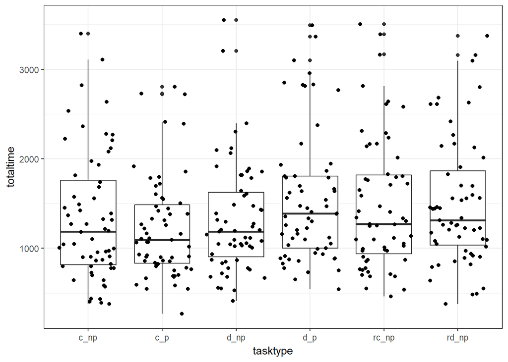

```r
ggplot(ads, aes(tasktype, totaltime)) + geom_boxplot() + geom_jitter()
```

```r
#pretest score
ddply(ads, ~tasktype, summarise, mean=mean(prescore, na.rm=TRUE), sd=sd(prescore, na.rm=TRUE))
```

```
##   tasktype     mean       sd
## 1     c_np 1.781250 1.408238
## 2      c_p 2.000000 1.450327
## 3     d_np 1.898305 1.282440
## 4      d_p 2.048387 1.335854
## 5    rc_np 1.864407 1.431874
## 6    rd_np 2.101695 1.422660
```

```r
summary(aov(prescore~tasktype, data=ads)) #make sure there are no noticeable differences messing up randomization
```

```
##              Df Sum Sq Mean Sq F value Pr(>F)
## tasktype      5    4.5  0.9031   0.468    0.8
## Residuals   356  687.5  1.9311
```

# Recall task analysis (KL divergence)

## Set up for calculating KL

### Reference distributions: Discrete normal dist for a fixed interval size

To calculate KL divergence, we will use a discretized normal distribution. First, we’ll derive that discrete reference distribution that we will use to calculate KLD. This will be the true sampling distribution (see paper for the terminology we are using to describe each distribution).

```r
#for recall
recall_n = 40
recall_true_mu = 250
recall_true_sd = 150
recall_true_se = recall_true_sd/sqrt(recall_n)

min_x = 0
max_x = 500
interval_size = 50

#derive discrete reference distribution
make_discrete_reference_dist = function(dist_fun, min_x, max_x, interval_size) {
  data_frame(
    x_min = seq(min_x, max_x - interval_size, by = interval_size),
    x_max = seq(min_x + interval_size, max_x, by = interval_size),
    x = (x_min + x_max)/2,   #midpoint of the interval
    #this difference sometimes comes out as 0 due to rounding errors in bins with very low probability
    #adjust it to always be at least xmin (smallest value > 0 on this machine).
    p = pmax(.Machine$double.xmin, dist_fun(x_max) - dist_fun(x_min))
    # p = dist_fun(x_max) - dist_fun(x_min)
  )
}

recall_true_sampling_ref_dist= make_discrete_reference_dist(
  function(x) pnorm(x, recall_true_mu, recall_true_se),
  min_x, max_x, interval_size
)
recall_true_sampling_ref_dist
```

```
## # A tibble: 10 x 4
##    x_min x_max     x             p
##    <dbl> <dbl> <dbl>         <dbl>
##  1     0    50    25  1.688316e-17
##  2    50   100    75  1.269814e-10
##  3   100   150   125  1.241318e-05
##  4   150   200   175  1.749508e-02
##  5   200   250   225  4.824925e-01
##  6   250   300   275  4.824925e-01
##  7   300   350   325  1.749508e-02
##  8   350   400   375  1.241318e-05
##  9   400   450   425  1.269814e-10
## 10   450   500   475 2.225074e-308
```

Let’s make sure the reference distribution looks right:

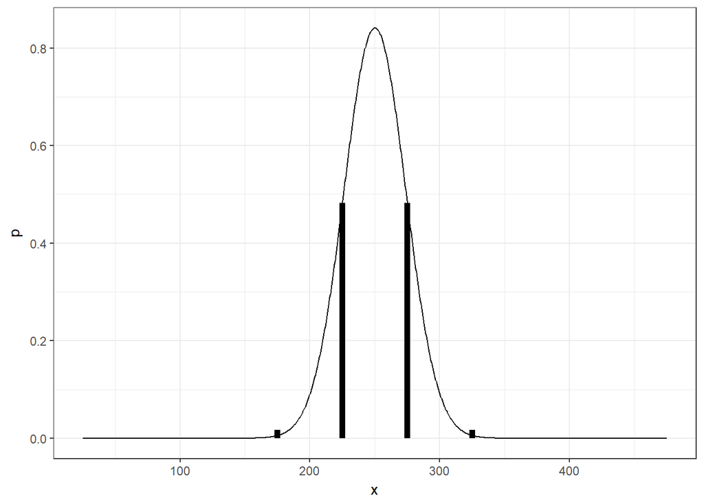

```r
recall_true_sampling_ref_dist %>%
    ggplot(aes(x = x, y = p)) +
    stat_function(fun = function(x) dnorm(x, recall_true_mu, recall_true_se) * interval_size, n = 1001) +
    geom_segment(aes(xend = x, y = 0, yend = p), size = 2)
```

We could also make comparisons to other reference distributions for predictions based on the sample shown to participants. That sample had these properties:

```r
recall_sample_mu = 268
recall_sample_sd = 151
recall_sample_se = recall_sample_sd/sqrt(recall_n)

recall_nu = recall_n - 1      #degrees of freedom
```

Here is a plot of some possible distributions to compare against:

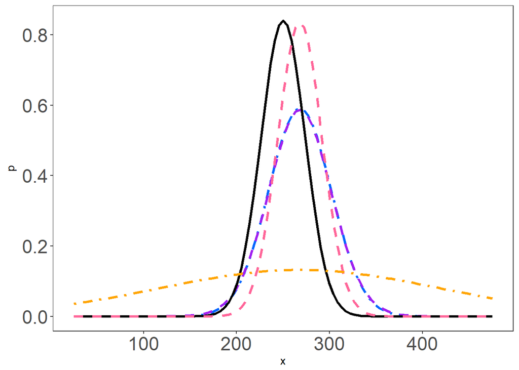

```r
recall_true_sampling_ref_dist %>%
  ggplot(aes(x = x, y = p)) +
  # predictive dist - Leek
  stat_function(fun = function(x) dnorm(x, recall_sample_mu, sqrt(2)*recall_sample_se) * interval_size,
    color="#0066ff", linetype = "dotdash", size=1.2) +
  # predictive dist - Spence
  stat_function(fun = function(x) dTF(x, recall_sample_mu, sqrt(2)*recall_sample_se, recall_nu) * interval_size,
    color="purple", linetype="dashed", size=1.2) +
  #true sampling dist
  stat_function(fun = function(x) dnorm(x, recall_true_mu, recall_true_se) * interval_size,
    size=1.2) +
  #observed sampling dist
  stat_function(fun = function(x) dnorm(x, recall_sample_mu, recall_sample_se) * interval_size,
    color="#ff6699", linetype = 2, size=1.2) +
  #observed population dist
  stat_function(fun = function(x) dnorm(x, recall_sample_mu, recall_sample_sd) * interval_size,
    color="orange", linetype = "dotdash", size=1.2) +
  theme(axis.text=element_text(size=18),
    # axis.text.y=element_blank(),
    panel.grid.major = element_blank(), panel.grid.minor = element_blank())
```

For this experiment, the Leek (blue) and Spence (purple) predictive dists are essentially equivalent. We are comparing against the true sampling distribution (black) because that is what participants saw after their prediction.

### Discrete KLD calculation (method 1)

Now let’s make a function that takes a reference distribution as returned by `make_reference_dist` and a vector of discrete guesses on the same bins and returns the KLD.

```r
kld_discrete = function(reference_dist, guesses) {
  #responses with 20 balls appear to be recorded as being out of 100, so
  #instead of assuming some number here we'll just make this out of the
  #total of the supplied guesses
  guesses = guesses / sum(guesses)
  smoothing_denominator = 1000
  n_atoms = nrow(recall_true_sampling_ref_dist)

  #make sure the number of supplied guesses is the same as the atoms in the reference dist
  stopifnot(n_atoms == length(guesses))

  #calculate smoothed guesses (guaranteed to have no 0s and sum to 1)
  estimated_p = (guesses * smoothing_denominator + 1) / (smoothing_denominator + n_atoms)

  #assert we have normalized everything correctly (within a reasonable tolerance)
  stopifnot(isTRUE(all.equal(sum(reference_dist$p), 1, tolerance = 0.01)))
  stopifnot(isTRUE(all.equal(sum(estimated_p), 1, tolerance = 0.01)))

  #since we have normalized everything correctly, we can use the KLD formula directly
  #instead of calling KLD (which renormalizes again)
  sum(reference_dist$p * (log(reference_dist$p) - log(estimated_p)))
}
```

**Method 1**: Use smoothing to eliminate non-zeros (see [here](https://mathoverflow.net/q/72672)) and compare against discretization normal dist.

```r
df2dr$kl_disc = apply(df2dr, 1, function(row) {
  guesses = as.numeric(strsplit(as.character(row["binprob"]), ",")[[1]])
  kld_discrete(recall_true_sampling_ref_dist, guesses)
})
```

#### Alternative approach to KLD (methods 2 and 3)

Here we’ll use code based on a simplified version of `LaplacesDemon::KLD` that does not try to guess if it is given `log(p)` or `p` (that guessing introduces bugs in the case of 0s). We’ve also changed the syntax to match https://en.wikipedia.org/wiki/Kullback–Leibler_divergence. To quote that article, KL divergence is “the amount of information lost when Q is used to approximate P.”

Here, $P$ is the distribution we’re trying to elicit and $Q$ is the participant’s approximation to it.

$$\begin{eqnarray}
kld(p, q) & = & D_{KL}(P || Q)\\
& = & \sum_i P(i) log \frac{P(i)}{Q(i)}\\
& = & \sum_i P(i)[log(P(i)) - log(Q(i))]
\end{eqnarray}$$
In case of zeros, we’ll replace them with `0.000001`. Implicitly, this ends up being a smoothing parameter as well, just of a different sort.

```r
kld = function(p, q) {
  stopifnot(identical(length(q), length(p)))
  stopifnot(all(is.finite(q)) && all(is.finite(p)))
  stopifnot(all(p > 0))   #ref dists will not have 0s
  q[which(q == 0)] <- .000001
  q <- q/sum(q)
  p <- p/sum(p)
  sum(p * (log(p) - log(q)))
}
```

**Method 2:** Replace zeros with `0.000001` and compare against discretized normal dist.

```r
df2dr$kl_disc_zeros = apply(df2dr, 1, function(row) {
  guesses = as.numeric(strsplit(as.character(row["binprob"]), ",")[[1]])
  kld(recall_true_sampling_ref_dist$p, guesses/sum(guesses))
})
```

**Method 3:** Replace zeros with `0.000001` and compare against density of continuous normal dist.

```r
df2dr$kl_cont_zeros = apply(df2dr, 1, function(row) {
  guesses = as.numeric(strsplit(as.character(row["binprob"]), ",")[[1]])
  kld(dnorm(recall_true_sampling_ref_dist$x, recall_true_mu, recall_true_se), guesses/sum(guesses))
})
```

#### Comparing the three approaches

Method 1 versus method 2 (black line is y = x):

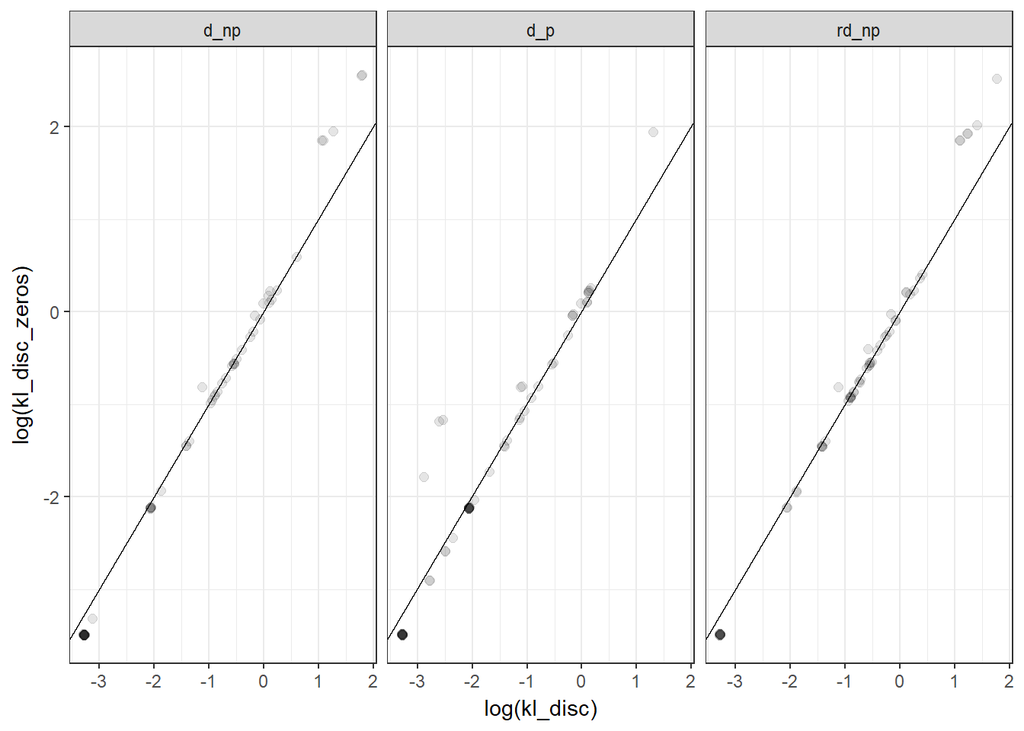

```r
df2dr %>%
  ggplot(aes(x = log(kl_disc), y = log(kl_disc_zeros))) +
  geom_point(position=position_jitter(width=.01, height=.01), alpha=.1, pch=19, size=2) +
  geom_abline(intercept = 0, slope = 1) +
  facet_wrap(~ condition)
```

Method 1 verus method 3:

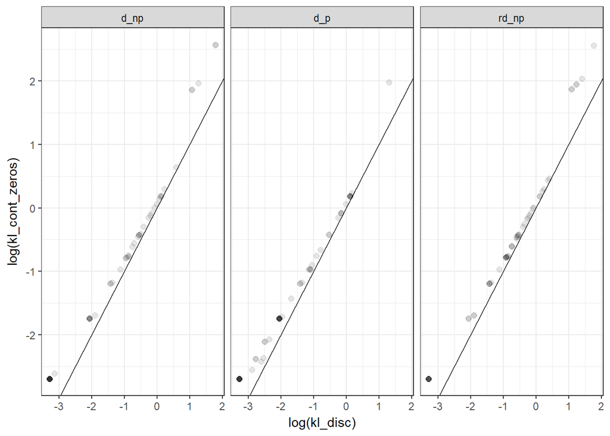

```r
df2dr %>%
  ggplot(aes(x = log(kl_disc), y = log(kl_cont_zeros))) +
  geom_point(alpha=.1, pch=19, size=2) +
  geom_abline(intercept = 0, slope = 1) +
  facet_wrap(~ condition)
```

As expected, comparing the discrete distribution against the continuous version adds some upward bias (likely due to underestimating the probability close to the mode and overestimating tails; see [continuity correction](https://en.wikipedia.org/wiki/Continuity_correction)).

The larger differences are due to differences in how to handle zeros when calculating KL divergence. We have not come across a clearly better method (the first method uses smoothing that requires a choice of smoothing parameter, the second may disadvantage the continuous condition, and the third may disadvantage the discrete condition). Instead we will examine all three.

### Continuous KLD

For our first approach, we’ll convert the input curves into continuous functions and then take the area under the curve in each reference bin, then compare against the discretized normal dist.

Given the guessed x and y values, we use spline fitting to convert these into a function (which is appropriate here because spline fitting was also used in the visual feedback as people *input* these functions).

Say we had a pretty good guess (actual in black, guess in red):

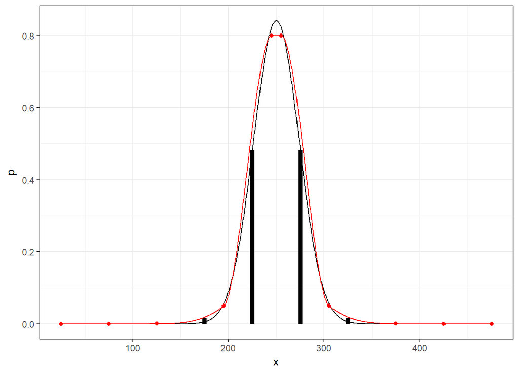

```r
guessed_x = c(25, 75, 125, 195, 245, 255, 305, 375, 425, 475)
guessed_y = dnorm(guessed_x, recall_true_mu, recall_true_se)
guessed_y = c(0, 0, 0.00001, 0.001, 0.016, 0.016, 0.001, 0.00001, 0, 0)
guessed_fun = splinefun(guessed_x, guessed_y, "monoH.FC")
guessed_fun_gt0 = function(x) pmax(guessed_fun(x), 0)

recall_true_sampling_ref_dist %>%
  ggplot(aes(x = x, y = p)) +
  stat_function(fun = function(x) dnorm(x, recall_true_mu, recall_true_se) * interval_size, n = 1001) +
  geom_segment(aes(xend = x, y = 0, yend = p), size = 2) +
  stat_function(fun = function(x) guessed_fun_gt0(x) * interval_size, color="red", n=1001)  +
  geom_point(data = data.frame(x = guessed_x, p = guessed_y * interval_size), color="red")
```

Let’s make a function that compares the areas under the curve to our discrete reference distribution areas using KLD:

```r
kld_continuous = function(reference_dist, guessed_x, guessed_y) {
  guessed_fun = splinefun(guessed_x, guessed_y, "monoH.FC")

  #to be well-defined we must make sure the curve is >= 0
  #(actually, > 0, but this is handled in kld_discrete())
  guessed_fun_gt0 = function(x) pmax(guessed_fun(x), 0)

  #verify all x values are approximately in their bins (sometimes it is out by 1)
  stopifnot(all(
    reference_dist$x_min - ceiling(guessed_x) <= 1  &
    floor(guessed_x) - reference_dist$x_max <= 1))

  #get the area under the entire guessed curve
  area_under_curve = integrate(guessed_fun_gt0, min(reference_dist$x_min), max(reference_dist$x_max))$value

  #then, for each bin defined by the reference dist,
  #determine the proportion of the area under the guessed curve that is in that bin
  guesses = apply(reference_dist, 1, function(.)
    integrate(guessed_fun_gt0, .["x_min"], .["x_max"])$value / area_under_curve)

  kld_discrete(reference_dist, guesses)
}
```

**Method 1:** Use spline-fitting and numerical integration to calculate the area under the curve in each bin from the discrete normal dist, and compare against the discrete normal dist.

```r
df2cr$kl_disc = apply(df2cr, 1, function(row) {
  guessed_y = as.numeric(strsplit(as.character(row["binprob"]), ",")[[1]])
  guessed_x = as.numeric(strsplit(as.character(row["binx"]), "_")[[1]])
  kld_continuous(recall_true_sampling_ref_dist, guessed_x, guessed_y)
})
```

**Method 2:** Normalize by max guess and replace zeros with `0.000001`, then compare against normal dist at corresponding densities.

```r
df2cr$kl_cont_zeros = apply(df2cr, 1, function(row) {
  guessed_y = as.numeric(strsplit(as.character(row["binprob"]), ",")[[1]])
  guessed_x = as.numeric(strsplit(as.character(row["binx"]), "_")[[1]])
  kld(dnorm(guessed_x, recall_true_mu, recall_true_se), guessed_y/sum(guessed_y))
})
```

**Method 3:** No method 3 here, but we’ll match up method 2 in continuous with both method 2 and 3 of the discrete dist.

```r
df2cr$kl_disc_zeros = df2cr$kl_cont_zeros
```

#### Comparing the approaches

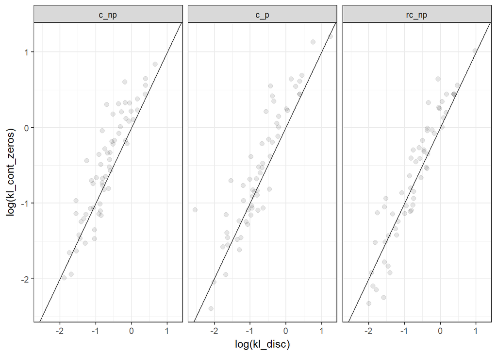

```r
df2cr %>%
  ggplot(aes(x = log(kl_disc), y = log(kl_cont_zeros))) +
  geom_point(alpha=.1, pch=19, size=2) +
  geom_abline(intercept = 0, slope = 1) +
  facet_wrap(~ condition)
```

It looks like the results are similar, with a slight downward bias when using the discrete method. Again, we have not come across a clearly better method (the first method is more involved, using spline-fitting and discretization with smoothing that requires a choice of smoothing parameter, the second may disadvantage discrete or continous depending on how we convert discrete into something comparable to the continuous distribution). There does appear to be systematic differences, but those differences don’t appear to disadvantage any particular condition, and they aren’t large relative to the variance.

## Combine the discrete and continuous and add prescore

We combine the discrete and continuous conditions into a single dataframe and add the literacy prescore.

```r
adfr <- rbind(df2dr, df2cr)

adsL.first <- adsL[match(unique(adsL$workerId), adsL$workerId),]
worker_prescore <- adsL.first[,c("workerId","prescore")]

adfr = merge(adfr, worker_prescore, by = intersect(names(adfr), names(worker_prescore)))
```

## Some descriptive statistics

Log of KLD across conditions:

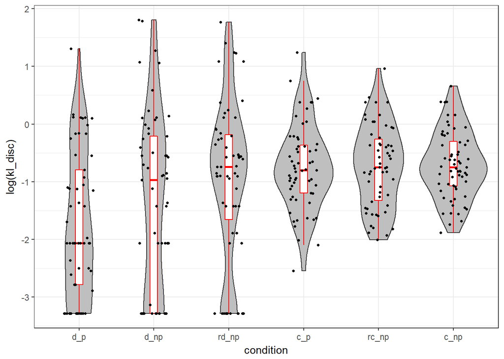

```r
adfr %>%
  mutate(condition = reorder(condition, log(kl_disc))) %>%
  ggplot(aes(x = condition, y = log(kl_disc))) +
  geom_violin(fill = "gray75") +
  geom_boxplot(width = 0.1, color = "red", outlier.color = NA) +
  geom_jitter(pch=20, width = .2)
```

Discrete conditions have lower KLD for some people compared to the continuous conditions. This is consistent with our model-based results (below): sometimes lower means but higher variance.

```r
adfr %<>% mutate(
  discrete = ifelse(condition == "d_p" | condition == "d_np" | condition == "r_np", 1, 0),
  predict = ifelse(condition == "d_p" | condition == "c_p", 1, 0),
  rules = ifelse(condition == "rd_np" | condition == "rc_np", 1, 0)
)

ddply(adfr, ~discrete, summarise, median=median(kl_cont_zeros, na.rm=TRUE), sd=sd(kl_cont_zeros, na.rm=TRUE))
```

```
##   discrete   median       sd
## 1        0 0.545092 1.308610
## 2        1 0.211807 2.023035
```

```r
ddply(adfr, ~predict, summarise, median=median(kl_cont_zeros, na.rm=TRUE), sd=sd(kl_cont_zeros, na.rm=TRUE))
```

```
##   predict    median        sd
## 1       0 0.5246094 1.8300519
## 2       1 0.3670446 0.8503104
```

```r
ddply(adfr, ~rules, summarise, median=median(kl_cont_zeros, na.rm=TRUE), sd=sd(kl_cont_zeros, na.rm=TRUE))
```

```
##   rules    median       sd
## 1     0 0.4435176 1.479061
## 2     1 0.5450920 1.763239
```

```r
#summarize error in mean and sd of recalled versus shown
#first means
ddply(adfr, ~condition, summarise,
  mean=mean(merrs, na.rm=TRUE),
  sd=sd(merrs, na.rm=TRUE),
  #mean/sd won't be great summaries given the skewed distribution
  median = median(merrs, na.rm=TRUE),
  mad = mad(merrs, na.rm=TRUE))
```

```
##   condition      mean       sd     median      mad
## 1      c_np -7.281416 27.82272  -9.094983 22.01751
## 2       c_p -6.678593 36.46608 -18.589504 21.17128
## 3      d_np -1.105725 37.18524   0.000000  0.00000
## 4       d_p -8.230092 22.68598   0.000000  0.00000
## 5     rc_np -6.028576 33.56197  -8.250356 23.19858
## 6     rd_np -1.885222 28.73661   0.000000  0.00000
```

```r
#absolute differences means
ddply(adfr, ~condition, summarise,
  mean=mean(amerrs, na.rm=TRUE),
  sd=sd(amerrs, na.rm=TRUE),
  #mean/sd won't be great summaries given the skewed distribution
  median = median(amerrs, na.rm=TRUE),
  mad = mad(amerrs, na.rm=TRUE))
```

```
##   condition     mean       sd   median      mad
## 1      c_np 21.34107 19.10718 16.91906 12.17472
## 2       c_p 26.35459 25.84972 21.47937 14.02459
## 3      d_np 17.40305 32.79805  0.00000  0.00000
## 4       d_p 13.29277 20.09663  0.00000  0.00000
## 5     rc_np 23.83795 24.17957 18.91181 17.60933
## 6     rd_np 16.37675 23.59208  0.00000  0.00000
```

```r
#sds
ddply(adfr, ~condition, summarise,
  mean=mean(serrs, na.rm=TRUE),
  sd=sd(serrs, na.rm=TRUE),
  #mean/sd won't be great summaries given the skewed distribution
  median = median(serrs, na.rm=TRUE),
  mad = mad(serrs, na.rm=TRUE))
```

```
##   condition       mean       sd    median      mad
## 1      c_np -20.950701 40.08703 -13.18848 36.46481
## 2       c_p  -6.208714 21.88456  -6.45835 23.99060
## 3      d_np -34.604594 32.07579 -23.57818 19.10020
## 4       d_p -19.737024 17.90720 -17.64143 10.29836
## 5     rc_np -14.839344 33.32182 -11.13651 32.16820
## 6     rd_np -41.429624 30.46904 -33.63685 34.01318
```

```r
#absolute difference sds
ddply(adfr, ~condition, summarise,
  mean=mean(aserrs, na.rm=TRUE),
  sd=sd(aserrs, na.rm=TRUE),
  #mean/sd won't be great summaries given the skewed distribution
  median = median(aserrs, na.rm=TRUE),
  mad = mad(aserrs, na.rm=TRUE))
```

```
##   condition     mean       sd   median      mad
## 1      c_np 32.69803 31.08713 23.71708 20.10962
## 2       c_p 18.78150 12.61455 21.04986 10.43729
## 3      d_np 34.60459 32.07579 23.57818 19.10020
## 4       d_p 19.73702 17.90720 17.64143 10.29836
## 5     rc_np 27.38228 23.89464 23.71708 16.28626
## 6     rd_np 41.42962 30.46904 33.63685 34.01318
```

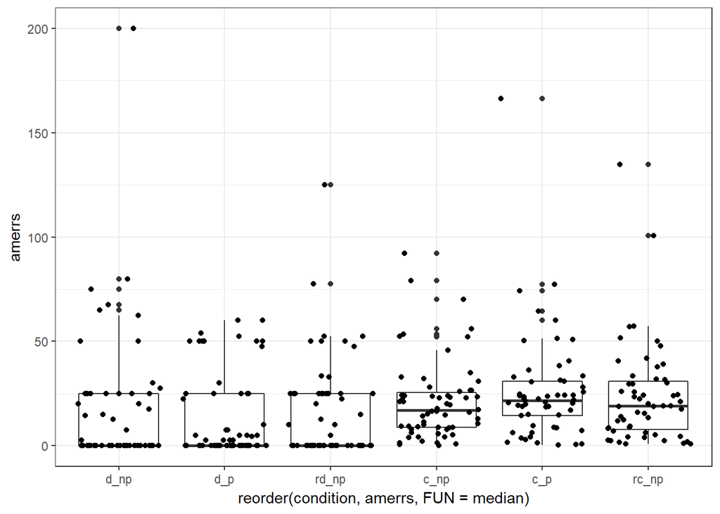

```r
#plot for overview of how many perfectly recalled in each condition (dots at 0 on y)
ggplot(adfr, aes(x=reorder(condition, amerrs, FUN=median), amerrs)) + geom_boxplot() + geom_jitter()
```

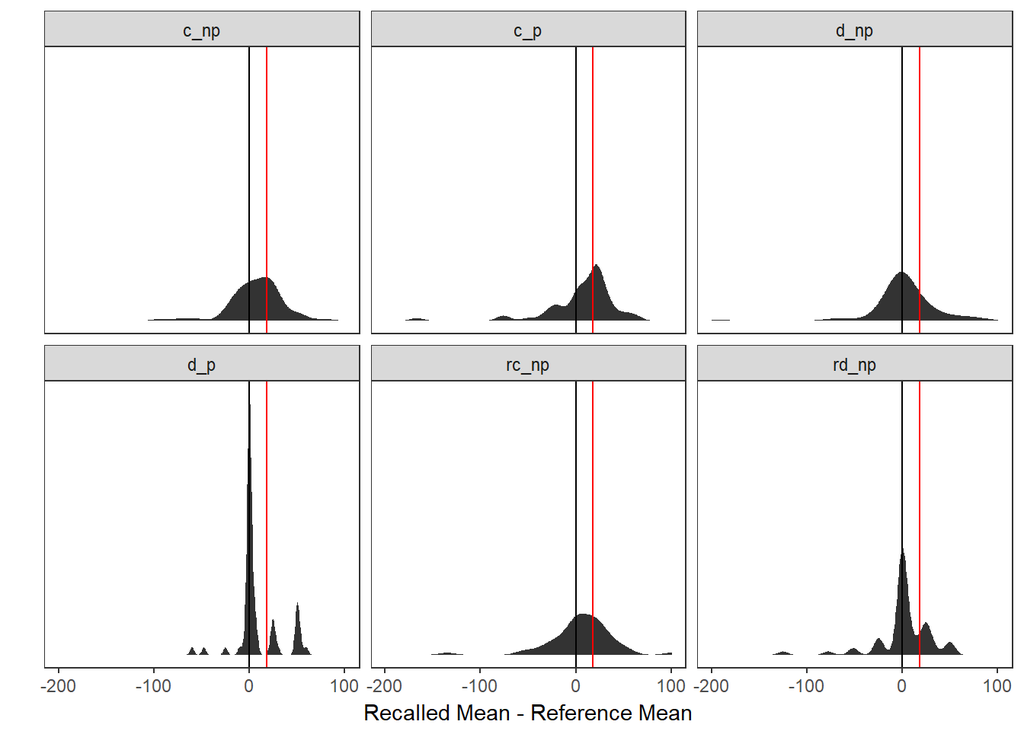

```r
#distribution of errors in means - recalled
adfr %>%
  ggplot(aes(x = means - 250)) +
  stat_density() +
  facet_wrap(~condition) +
  geom_vline(xintercept = 0, color="black") +
  theme(axis.text.y=element_blank(), axis.ticks.y=element_blank(),
    panel.grid.major = element_blank(), panel.grid.minor = element_blank()) +
  labs(x="Recalled Mean - Reference Mean",  y="") +
  geom_vline(xintercept = 18, color="red")
```

```r
  #use red for sample sampling dist, black for pop sampling dist, blue for predictive, orange for data dist
```

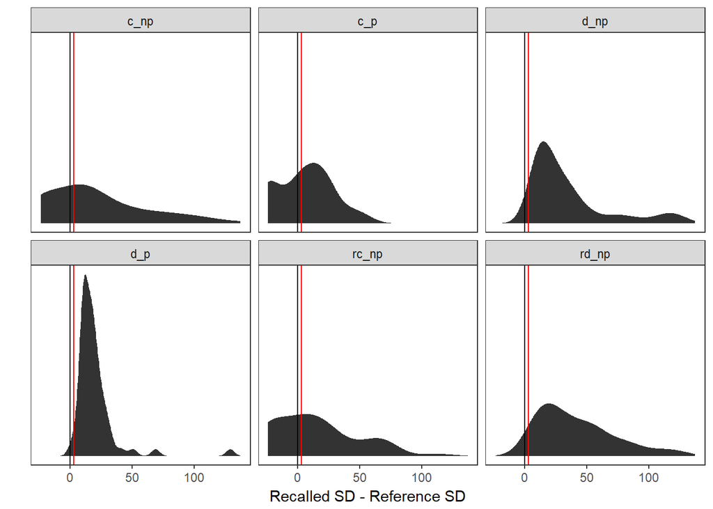

```r
#distribution of errors in sd - recalled
adfr %>%
ggplot(aes(x = sds - 150/sqrt(40))) + stat_density() +
    facet_wrap(~condition) +
    geom_vline(xintercept = 0, color="black") + theme(axis.text.y=element_blank(), axis.ticks.y=element_blank(), panel.grid.major = element_blank(), panel.grid.minor = element_blank()) + labs(x="Recalled SD - Reference SD",  y="") + geom_vline(xintercept = 2.85, color="red") #+ geom_vline(xintercept = 144, color="orange")
```

```r
#counts of how many people perfectly recalled in discrete
by(adfr, adfr$condition, function(means) sum(means==250, na.rm=TRUE))
```

```
## adfr$condition: c_np
## [1] 0
## --------------------------------------------------------
## adfr$condition: c_p
## [1] 0
## --------------------------------------------------------
## adfr$condition: d_np
## [1] 32
## --------------------------------------------------------
## adfr$condition: d_p
## [1] 31
## --------------------------------------------------------
## adfr$condition: rc_np
## [1] 0
## --------------------------------------------------------
## adfr$condition: rd_np
## [1] 30
```

```r
#by percentage
by(adfr, adfr$condition, function(means) sum(means==250, na.rm=TRUE)/nrow(means))
```

```
## adfr$condition: c_np
## [1] 0
## --------------------------------------------------------
## adfr$condition: c_p
## [1] 0
## --------------------------------------------------------
## adfr$condition: d_np
## [1] 0.5614035
## --------------------------------------------------------
## adfr$condition: d_p
## [1] 0.5081967
## --------------------------------------------------------
## adfr$condition: rc_np
## [1] 0
## --------------------------------------------------------
## adfr$condition: rd_np
## [1] 0.5084746
```

## Frequentist model

A model of log(kl) that accounts for different variance in different conditions:

```r
#first, set seed so results don't differ slightly each time from convergence process

#center prescore
adfr$prescore_c <- adfr$prescore - mean(adfr$prescore)

adfr_gamlss = adfr %>%
  #gamlss needs all columns not to have NAs
  dplyr::select(discrete, predict, rules, prescore_c, kl_disc, kl_disc_zeros, kl_cont_zeros)

mg = gamlss(log(kl_cont_zeros) ~ discrete*predict + rules + prescore_c,
  sigma.formula = ~ discrete*predict + rules + prescore_c,
  data=adfr_gamlss)
```

```
## GAMLSS-RS iteration 1: Global Deviance = 1002.663
## GAMLSS-RS iteration 2: Global Deviance = 1002.183
## GAMLSS-RS iteration 3: Global Deviance = 1002.182
```

```r
summary(mg)
```

```
## Family:  c("NO", "Normal")
##
## Call:  gamlss(formula = log(kl_cont_zeros) ~ discrete * predict +
##     rules + prescore_c, sigma.formula = ~discrete *
##     predict + rules + prescore_c, data = adfr_gamlss)
##
## Fitting method: RS()
##
## ------------------------------------------------------------------
## Mu link function:  identity
## Mu Coefficients:
##                  Estimate Std. Error t value Pr(>|t|)
## (Intercept)      -0.53516    0.08658  -6.181 1.79e-09 ***
## discrete         -0.45787    0.20802  -2.201   0.0284 *
## predict          -0.03225    0.13270  -0.243   0.8081
## rules            -0.12871    0.13148  -0.979   0.3283
## prescore_c       -0.14279    0.03578  -3.991 8.03e-05 ***
## discrete:predict -0.41354    0.27111  -1.525   0.1281
## ---
## Signif. codes:  0 '***' 0.001 '**' 0.01 '*' 0.05 '.' 0.1 ' ' 1
##
## ------------------------------------------------------------------
## Sigma link function:  log
## Sigma Coefficients:
##                  Estimate Std. Error t value Pr(>|t|)
## (Intercept)      -0.37615    0.08958  -4.199 3.42e-05 ***
## discrete          0.72922    0.13015   5.603 4.32e-08 ***
## predict           0.12189    0.12906   0.944    0.346
## rules             0.44342    0.11128   3.985 8.24e-05 ***
## prescore_c        0.03509    0.02651   1.324    0.186
## discrete:predict -0.38916    0.18382  -2.117    0.035 *
## ---
## Signif. codes:  0 '***' 0.001 '**' 0.01 '*' 0.05 '.' 0.1 ' ' 1
##
## ------------------------------------------------------------------
## No. of observations in the fit:  357
## Degrees of Freedom for the fit:  12
##       Residual Deg. of Freedom:  345
##                       at cycle:  3
##
## Global Deviance:     1002.182
##             AIC:     1026.182
##             SBC:     1072.715
```

## Bayesian model

An equivalent model in rethinking: (this is what we currently report)

```r
kld_model_spec = alist(
  kl ~ dlnorm(mu, sigma),
  mu <- mu_a + mu_bd*discrete + mu_bp*predict + mu_bdp*discrete*predict + mu_br*rules + mu_bpr*prescore_c,
  log(sigma) <- sigma_a + sigma_bd*discrete + sigma_bp*predict + sigma_bdp*discrete*predict +
    sigma_br*rules + sigma_bpr*prescore_c,
  mu_a ~ dnorm(0,5), #mean, sd
  mu_bd ~ dnorm(0,5),
  mu_bp ~ dnorm(0,5),
  mu_bdp ~ dnorm(0,5),
  mu_br ~ dnorm(0,5),
  mu_bpr ~ dnorm(0,5),
  sigma_a ~ dnorm(0,2.5),
  sigma_bd ~ dnorm(0,2.5),
  sigma_bp ~ dnorm(0,2.5),
  sigma_bdp ~ dnorm(0,2.5),
  sigma_br ~ dnorm(0,2.5),
  sigma_bpr ~ dnorm(0,2.5)
)

m_recall_disc = map2stan(kld_model_spec, data = adfr_gamlss %>% rename(kl = kl_disc))
```

[output not shown]

```
## Computing WAIC
```

```
## Constructing posterior predictions
```

```
## [ 100 / 1000 ]
[ 200 / 1000 ]
[ 300 / 1000 ]
[ 400 / 1000 ]
[ 500 / 1000 ]
[ 600 / 1000 ]
[ 700 / 1000 ]
[ 800 / 1000 ]
[ 900 / 1000 ]
[ 1000 / 1000 ]
```

```r
m_recall_disc_zeros = map2stan(kld_model_spec, data = adfr_gamlss %>% rename(kl = kl_disc_zeros))
```

```
## recompiling to avoid crashing R session
```

[output not shown]

```
## Computing WAIC
## Constructing posterior predictions
```

```
## [ 100 / 1000 ]
[ 200 / 1000 ]
[ 300 / 1000 ]
[ 400 / 1000 ]
[ 500 / 1000 ]
[ 600 / 1000 ]
[ 700 / 1000 ]
[ 800 / 1000 ]
[ 900 / 1000 ]
[ 1000 / 1000 ]
```

```r
m_recall_cont_zeros = map2stan(kld_model_spec, data = adfr_gamlss %>% rename(kl = kl_cont_zeros))
```

```
## recompiling to avoid crashing R session
```

[output not shown]

```
## Computing WAIC
## Constructing posterior predictions
```

```
## [ 100 / 1000 ]
[ 200 / 1000 ]
[ 300 / 1000 ]
[ 400 / 1000 ]
[ 500 / 1000 ]
[ 600 / 1000 ]
[ 700 / 1000 ]
[ 800 / 1000 ]
[ 900 / 1000 ]
[ 1000 / 1000 ]
```

### Coefficients of mean log(KLD)

First we’ll derive the coefficients for mu (the mean of log(KLD)). For a sensible display order we’ll use the following (we use this list later with `fct_relevel()` to make sure the coefficients are displayed in the order we want):

```r
coef_display_order = rev(c("intercept", "discrete", "predict", "discrete*predict", "rules", "literacy"))
```

Then we’ll extract samples of the coefficients from the model and display them as raindrop plots:

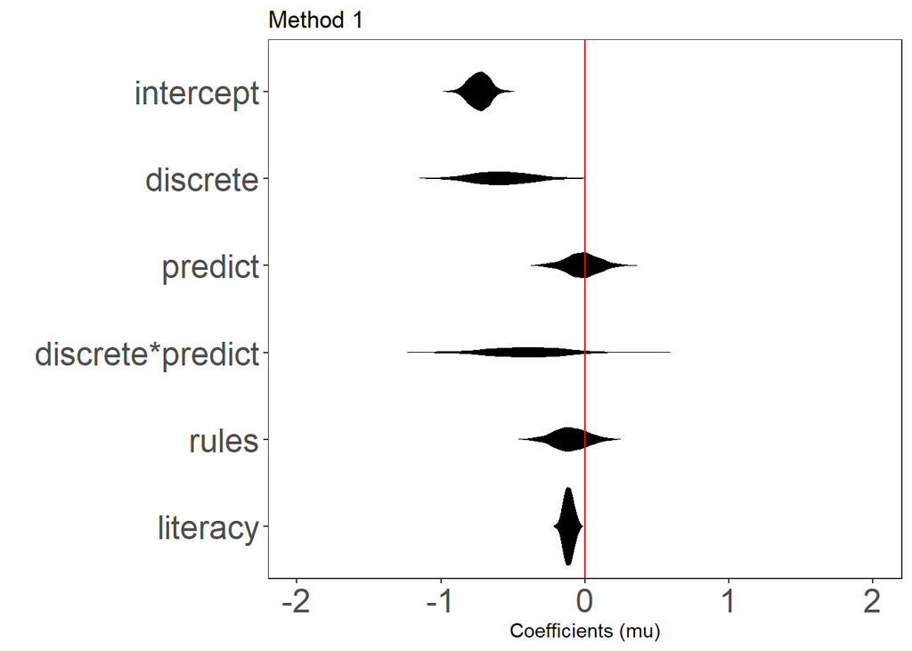

```r
plot_kld_model_mu_coefs = function(m) {
  mu_coefs = m %>%
    extract.samples() %>%
    as_data_frame() %>%
    transmute(
      intercept = mu_a,
      discrete = mu_bd,
      predict = mu_bp,
      `discrete*predict` = mu_bdp,
      rules = mu_br,
      literacy = mu_bpr
    ) %>%
    mutate(iteration = 1:n()) %>%
    gather(condition, estimate, -iteration) %>%
    mutate(condition = fct_relevel(condition, coef_display_order))

  mu_coefs %>%
    ggplot(aes(x = estimate, y = condition)) +
    geom_violinh(fill = "black", color = NA) +
    geom_vline(xintercept = 0, color = "red") +
    theme(axis.text=element_text(size=18),
    # axis.text.y=element_blank(),
    panel.grid.major = element_blank(), panel.grid.minor = element_blank()) +
    labs(x = "Coefficients (mu)", y = "")
}
plot_kld_model_mu_coefs(m_recall_disc) + xlim(-2, 2) + ggtitle("Method 1")
```

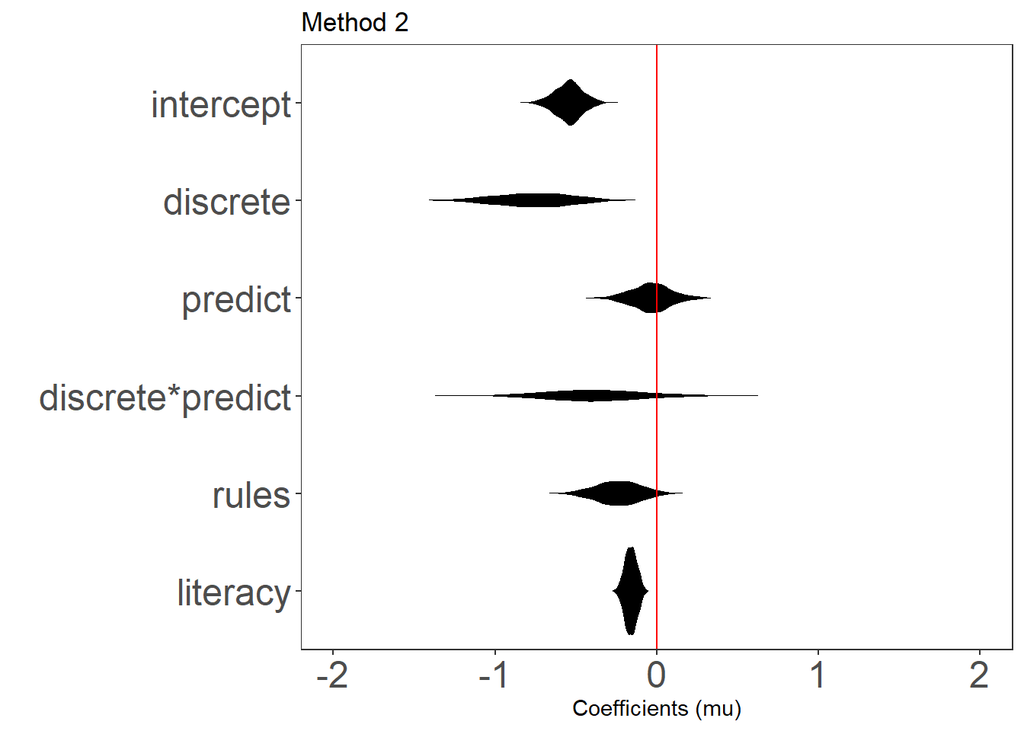

```r
plot_kld_model_mu_coefs(m_recall_disc_zeros) + xlim(-2, 2) + ggtitle("Method 2")
```

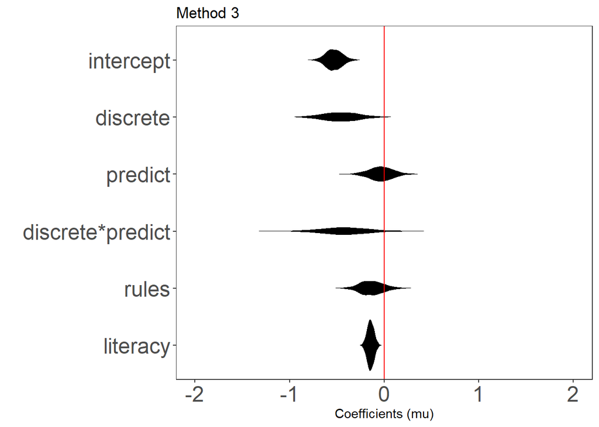

```r
plot_kld_model_mu_coefs(m_recall_cont_zeros) + xlim(-2, 2) + ggtitle("Method 3")
```

Broadly similar estimates using each approach.

### Coefficients of log(sd) of log(kld)

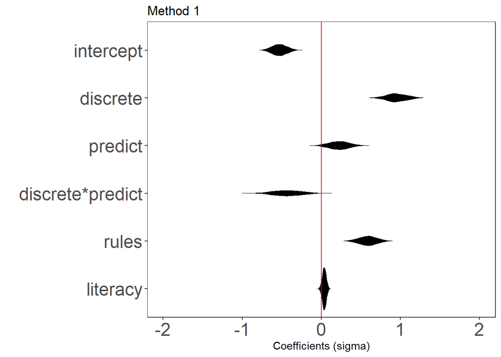

```r
plot_kld_model_sigma_coefs = function(m) {
  sigma_coefs = m %>%
    extract.samples() %>%
    as_data_frame() %>%
    transmute(
      intercept = sigma_a,
      discrete = sigma_bd,
      predict = sigma_bp,
      `discrete*predict` = sigma_bdp,
      rules = sigma_br,
      literacy = sigma_bpr
    ) %>%
    mutate(iteration = 1:n()) %>%
    gather(condition, estimate, -iteration) %>%
    mutate(condition = fct_relevel(condition, coef_display_order))

  sigma_coefs %>%
    ggplot(aes(x = estimate, y = condition)) +
    geom_violinh(fill = "black", color = NA) +
    geom_vline(xintercept = 0, color = "red") +
    theme(axis.text=element_text(size=18),
    # axis.text.y=element_blank(),
    panel.grid.major = element_blank(), panel.grid.minor = element_blank()) +
    labs(x = "Coefficients (sigma)", y = "")
}
plot_kld_model_sigma_coefs(m_recall_disc) + xlim(-2, 2) + ggtitle("Method 1")
```

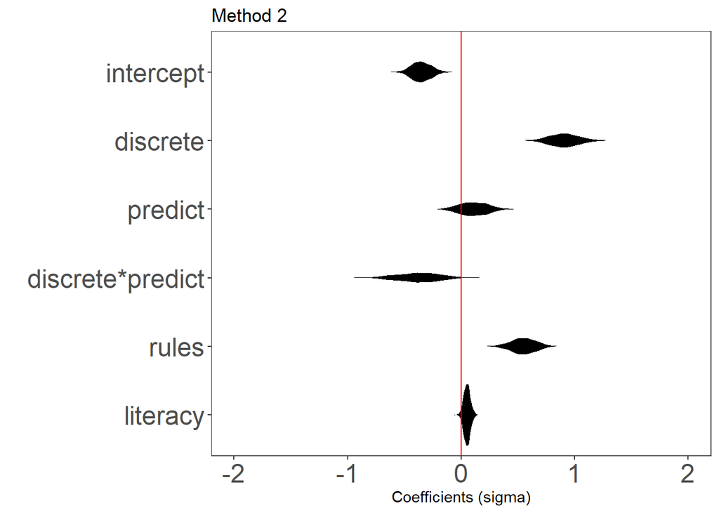

```r
plot_kld_model_sigma_coefs(m_recall_disc_zeros) + xlim(-2, 2) + ggtitle("Method 2")
```

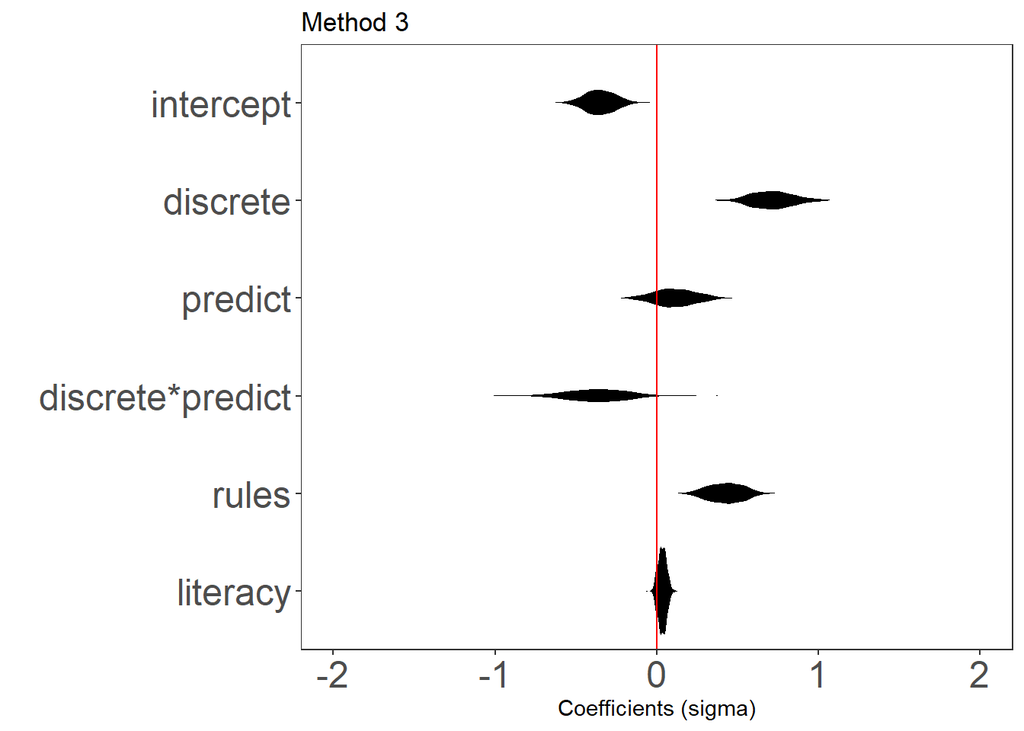

```r
plot_kld_model_sigma_coefs(m_recall_cont_zeros) + xlim(-2, 2) + ggtitle("Method 3")
```

Again, broadly similar estimates across models

### Expected values of mean and sd by condition

The previous plots show the estimates of the coefficients, which mostly gives us differences from the baseline condition (continuous + no predict), and in the case of `discrete*predict`, gives us difference from continuous + predict.

However, it can be useful to look at the estimated mean (or sd) on a per-condition basis (so-called marginal estimates). We can do that by using the coefficients to construct the marginal estimate of the parameter on a per-condition basis.

Again we’ll make a sensible display order first:

```r
estimate_display_order = rev(c("continuous none", "continuous predict", "continuous rules",
  "discrete none", "discrete predict", "discrete rules"))
```

#### Expected mu by condition

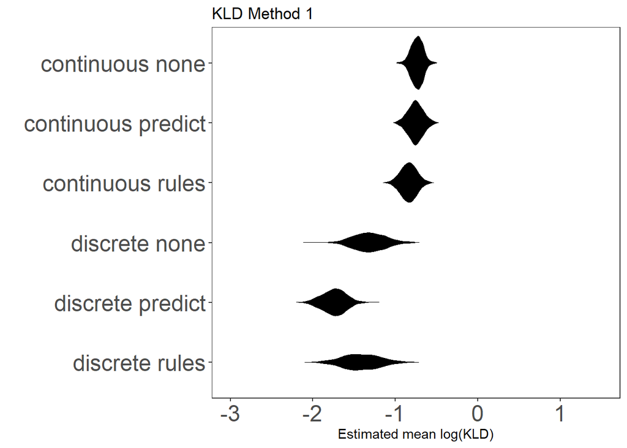

```r
plot_kld_model_expected_mu = function(m) {
  expected_mu = m %>%
    extract.samples() %>%
    as_data_frame() %>%
    transmute(
      `continuous none` = mu_a,
      `continuous predict` = mu_a + mu_bp,
      `continuous rules` = mu_a + mu_br,
      `discrete none` = mu_a + mu_bd,
      `discrete predict` = mu_a + mu_bd + mu_bp + mu_bdp,
      `discrete rules` = mu_a + mu_br + mu_bd
    ) %>%
    mutate(iteration = 1:n()) %>%
    gather(condition, estimate, -iteration) %>%
    mutate(condition = fct_relevel(condition, estimate_display_order))

  expected_mu %>%
    ggplot(aes(x = estimate, y = condition)) +
    geom_violinh(fill = "black", color = NA) +
    theme(axis.text=element_text(size=18),
    # axis.text.y=element_blank(),
    panel.grid.major = element_blank(), panel.grid.minor = element_blank()) +
    labs(x = "Estimated mean log(KLD)", y = "")
}
plot_kld_model_expected_mu(m_recall_disc) + xlim(-3,1.5) + ggtitle("KLD Method 1")
```

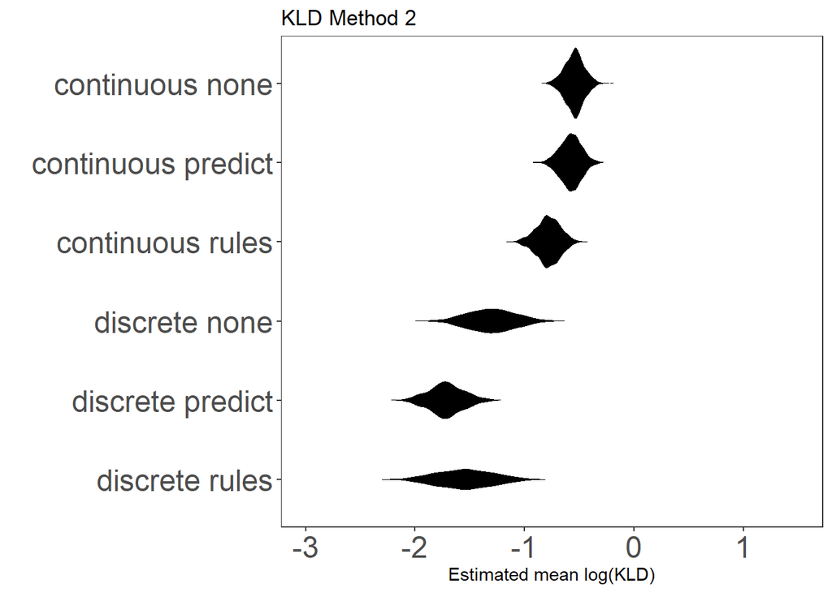

```r
plot_kld_model_expected_mu(m_recall_disc_zeros) + xlim(-3,1.5) + ggtitle("KLD Method 2")
```

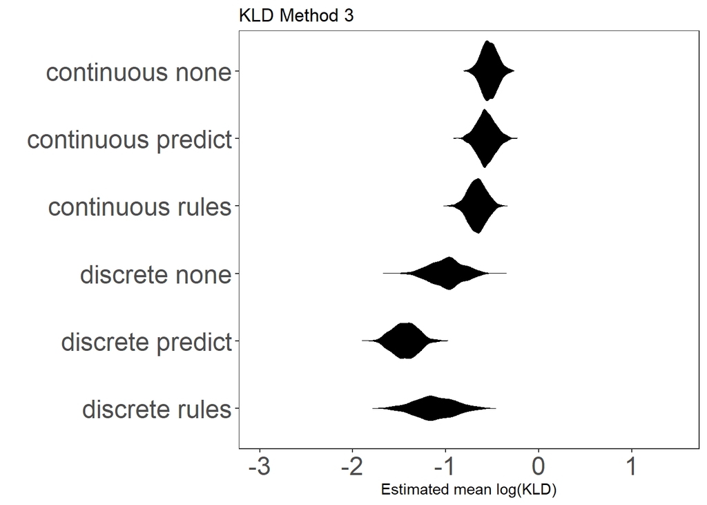

```r
plot_kld_model_expected_mu(m_recall_cont_zeros) + xlim(-3,1.5) + ggtitle("KLD Method 3")
```

#### Expected log(sd) by condition

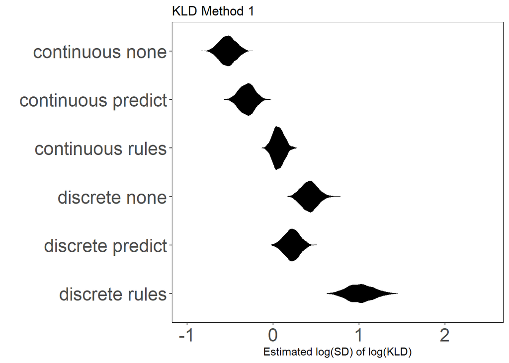

```r
plot_kld_model_expected_sigma = function(m) {
  expected_sigma = m %>%
    extract.samples() %>%
    as_data_frame() %>%
    transmute(
      `continuous none` = sigma_a,
      `continuous predict` = sigma_a + sigma_bp,
      `continuous rules` = sigma_a + sigma_br,
      `discrete none` = sigma_a + sigma_bd,
      `discrete predict` = sigma_a + sigma_bd + sigma_bp + sigma_bdp,
      `discrete rules` = sigma_a + sigma_br + sigma_bd
    ) %>%
    mutate(iteration = 1:n()) %>%
    gather(condition, estimate, -iteration) %>%
    mutate(condition = fct_relevel(condition, estimate_display_order))

  expected_sigma %>%
    ggplot(aes(x = estimate, y = condition)) +
    geom_violinh(fill = "black", color = NA) +
    theme(axis.text=element_text(size=18),
    # axis.text.y=element_blank(),
    panel.grid.major = element_blank(), panel.grid.minor = element_blank()) +
    labs(x = "Estimated log(SD) of log(KLD)", y = "")
}
plot_kld_model_expected_sigma(m_recall_disc) + xlim(-1, 2.5) + ggtitle("KLD Method 1")
```

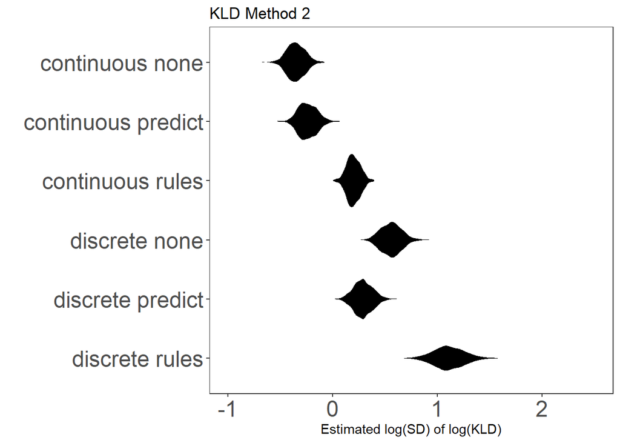

```r
plot_kld_model_expected_sigma(m_recall_disc_zeros) + xlim(-1, 2.5) + ggtitle("KLD Method 2")
```

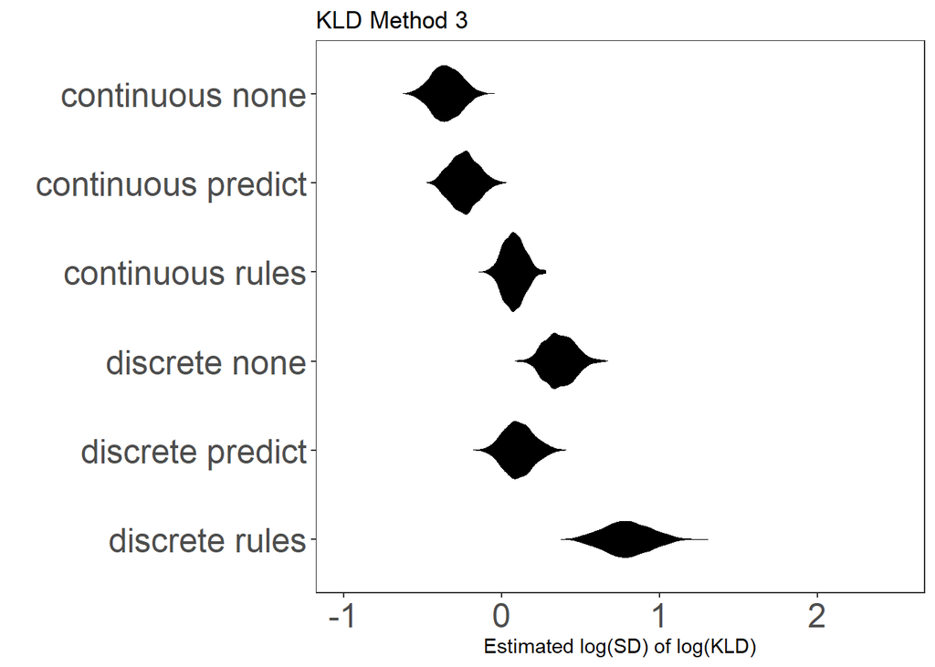

```r
plot_kld_model_expected_sigma(m_recall_cont_zeros) + xlim(-1, 2.5) + ggtitle("KLD Method 3")
```

# Transfer task analysis (KL divergence)

## Set up for calculating KL

### Reference distributions

First, make the reference distribution we’ll use to calculate KLD. Should be the predictive distribution in this case.

Our true sampling distribution will be based on these parameters:

```r
transfer_n = 8
transfer_true_mu = 0.75
transfer_true_sd = 1
transfer_true_se = transfer_true_sd / sqrt(transfer_n)
```

And participants observed a sample with these properties:

```r
transfer_sample_mu = 0.7
transfer_sample_sd = 1.1
transfer_sample_se = 1.1/sqrt(transfer_n)
transfer_nu = transfer_n - 1      #degrees of freedom
```

Our reference distribution will be calculated over this grid:

```r
min_x = -2.5
max_x = 2.5
interval_size = 0.5
```

Here is the Leek replication prediction reference distribution:

```r
transfer_leek_predictive_ref_dist = make_discrete_reference_dist(
  function(x) pnorm(x, transfer_sample_mu, transfer_sample_se*sqrt(2)), min_x, max_x, interval_size)
transfer_leek_predictive_ref_dist
```

```
## # A tibble: 10 x 4
##    x_min x_max     x            p
##    <dbl> <dbl> <dbl>        <dbl>
##  1  -2.5  -2.0 -2.25 4.545232e-07
##  2  -2.0  -1.5 -1.75 3.121374e-05
##  3  -1.5  -1.0 -1.25 9.660523e-04
##  4  -1.0  -0.5 -0.75 1.356375e-02
##  5  -0.5   0.0 -0.25 8.699594e-02
##  6   0.0   0.5  0.25 2.565074e-01
##  7   0.5   1.0  0.75 3.492147e-01
##  8   1.0   1.5  1.25 2.198229e-01
##  9   1.5   2.0  1.75 6.384929e-02
## 10   2.0   2.5  2.25 8.515707e-03
```

And a similar one, per Spence et al. (2006):

```r
transfer_spence_predictive_ref_dist = make_discrete_reference_dist(
  function(x) pTF(x, transfer_sample_mu, transfer_sample_se*sqrt(2), transfer_nu), min_x, max_x, interval_size)
transfer_spence_predictive_ref_dist
```

```
## # A tibble: 10 x 4
##    x_min x_max     x            p
##    <dbl> <dbl> <dbl>        <dbl>
##  1  -2.5  -2.0 -2.25 0.0005418546
##  2  -2.0  -1.5 -1.75 0.0017274296
##  3  -1.5  -1.0 -1.25 0.0061773416
##  4  -1.0  -0.5 -0.75 0.0239600771
##  5  -0.5   0.0 -0.25 0.0891448772
##  6   0.0   0.5  0.25 0.2415546645
##  7   0.5   1.0  0.75 0.3353780276
##  8   1.0   1.5  1.25 0.2066299213
##  9   1.5   2.0  1.75 0.0695237786
## 10   2.0   2.5  2.25 0.0182248648
```

And a reference distribution for the observed sampling distribution:

```r
transfer_observed_sampling_ref_dist = make_discrete_reference_dist(
  function(x) pnorm(x, transfer_sample_mu, transfer_sample_se), min_x, max_x, interval_size)
transfer_observed_sampling_ref_dist
```

```
## # A tibble: 10 x 4
##    x_min x_max     x            p
##    <dbl> <dbl> <dbl>        <dbl>
##  1  -2.5  -2.0 -2.25 1.925970e-12
##  2  -2.0  -1.5 -1.75 7.706703e-09
##  3  -1.5  -1.0 -1.25 6.170411e-06
##  4  -1.0  -0.5 -0.75 1.009679e-03
##  5  -0.5   0.0 -0.25 3.492171e-02
##  6   0.0   0.5  0.25 2.675977e-01
##  7   0.5   1.0  0.75 4.762266e-01
##  8   1.0   1.5  1.25 2.003968e-01
##  9   1.5   2.0  1.75 1.942643e-02
## 10   2.0   2.5  2.25 4.130147e-04
```

And one for the true sampling distribution:

```r
transfer_true_sampling_ref_dist = make_discrete_reference_dist(
  function(x) pnorm(x, transfer_true_mu, transfer_true_se), min_x, max_x, interval_size)
transfer_true_sampling_ref_dist
```

```
## # A tibble: 10 x 4
##    x_min x_max     x            p
##    <dbl> <dbl> <dbl>        <dbl>
##  1  -2.5  -2.0 -2.25 3.678905e-15
##  2  -2.0  -1.5 -1.75 9.830434e-11
##  3  -1.5  -1.0 -1.25 3.714509e-07
##  4  -1.0  -0.5 -0.75 2.031045e-04
##  5  -0.5   0.0 -0.25 1.674395e-02
##  6   0.0   0.5  0.25 2.228026e-01
##  7   0.5   1.0  0.75 5.204999e-01
##  8   1.0   1.5  1.25 2.228026e-01
##  9   1.5   2.0  1.75 1.674395e-02
## 10   2.0   2.5  2.25 2.031045e-04
```

Here is a plot of all of these distributions:

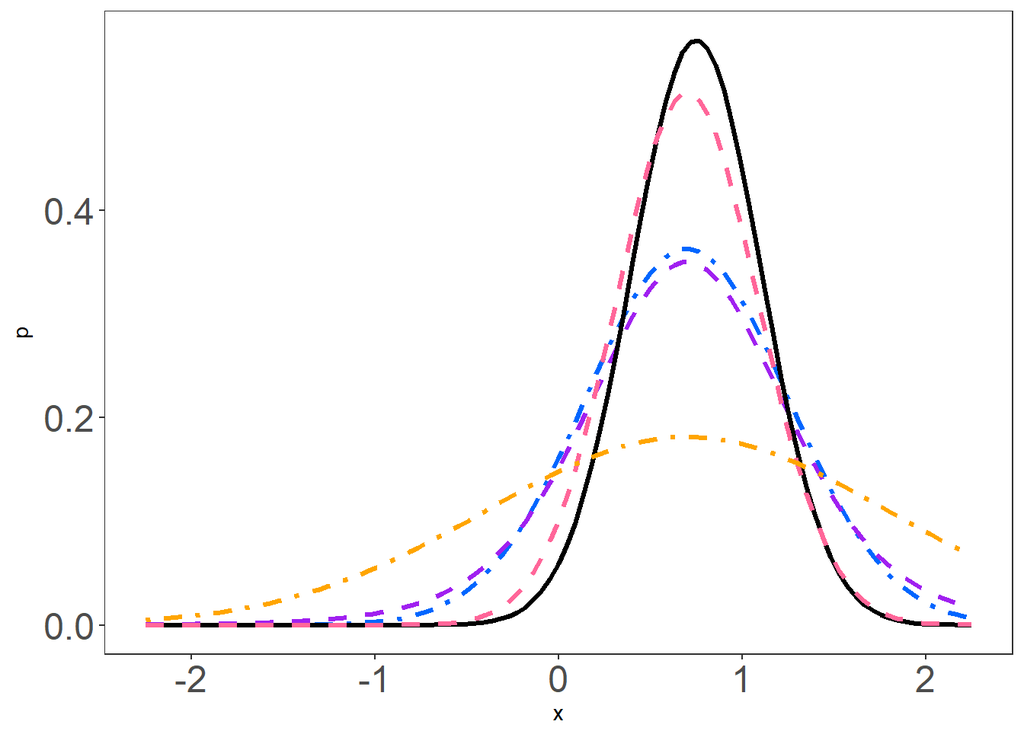

```r
transfer_true_sampling_ref_dist %>%
  ggplot(aes(x = x, y = p)) +
  # predictive dist - Leek
  stat_function(fun = function(x) dnorm(x, transfer_sample_mu, sqrt(2)*transfer_sample_se) * interval_size,
    color="#0066ff", linetype = "dotdash", size=1.2) +
  # predictive dist - Spence
  stat_function(fun = function(x) dTF(x, transfer_sample_mu, sqrt(2)*transfer_sample_se, transfer_nu) *
      interval_size, color="purple", linetype="dashed", size=1.2) +
  #true sampling dist
  stat_function(fun = function(x) dnorm(x, transfer_true_mu, transfer_true_se) * interval_size,
    size=1.2) +
  #observed sampling dist
  stat_function(fun = function(x) dnorm(x, transfer_sample_mu, transfer_sample_se) * interval_size,
    color="#ff6699", linetype = 2, size=1.2) +
  #observed population dist
  stat_function(fun = function(x) dnorm(x, transfer_sample_mu, transfer_sample_sd) * interval_size,
    color="orange", linetype = "dotdash", size=1.2) +
  theme(axis.text=element_text(size=18),
    # axis.text.y=element_blank(),
    panel.grid.major = element_blank(), panel.grid.minor = element_blank())
```

### Discrete KLD

Then derive KLD for the discrete responses:

```r
#method 1
df2dp$kl_disc = apply(df2dp, 1, function(row) {
  guesses = as.numeric(strsplit(as.character(row["binprob"]), ",")[[1]])
  kld_discrete(transfer_spence_predictive_ref_dist, guesses)
})

#method 2
df2dp$kl_disc_zeros = apply(df2dp, 1, function(row) {
  guesses = as.numeric(strsplit(as.character(row["binprob"]), ",")[[1]])
  kld(transfer_spence_predictive_ref_dist$p, guesses/sum(guesses))
})

#method 3
df2dp$kl_cont_zeros = apply(df2dp, 1, function(row) {
  guesses = as.numeric(strsplit(as.character(row["binprob"]), ",")[[1]])
  kld(dnorm(transfer_spence_predictive_ref_dist$x, transfer_true_mu, transfer_true_se), guesses/sum(guesses))
})

#method 1 for true sampling dist
df2dp$true_sampling_kl = apply(df2dp, 1, function(row) {
  guesses = as.numeric(strsplit(as.character(row["binprob"]), ",")[[1]])
  kld_discrete(transfer_true_sampling_ref_dist, guesses)
})

#method 1 for observed sampling dist
df2dp$observed_sampling_kl = apply(df2dp, 1, function(row) {
  guesses = as.numeric(strsplit(as.character(row["binprob"]), ",")[[1]])
  kld_discrete(transfer_observed_sampling_ref_dist, guesses)
})
```

#### Comparing the methods

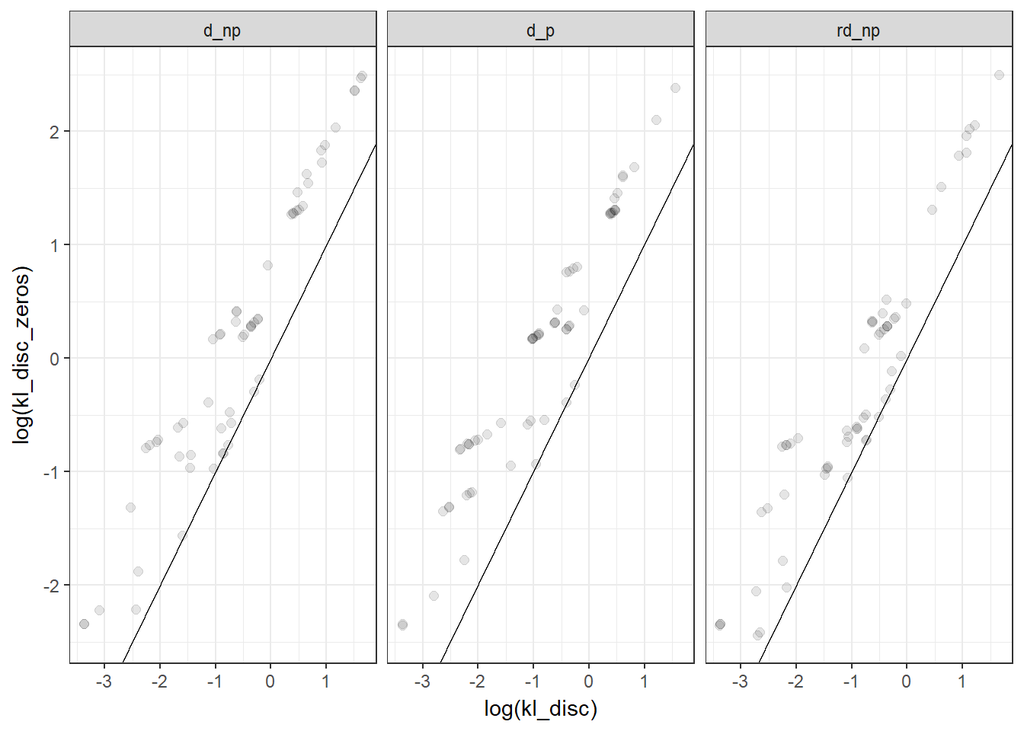

```r
df2dp %>%
  ggplot(aes(x = log(kl_disc), y = log(kl_disc_zeros))) +
  geom_point(position=position_jitter(width=.01, height=.01), alpha=.1, pch=19, size=2) +
  geom_abline(intercept = 0, slope = 1) +
  facet_wrap(~ condition)
```

Again, we’re seeing some systematic differences, but nothing large relative to the bias, and nothing that varies by condition.

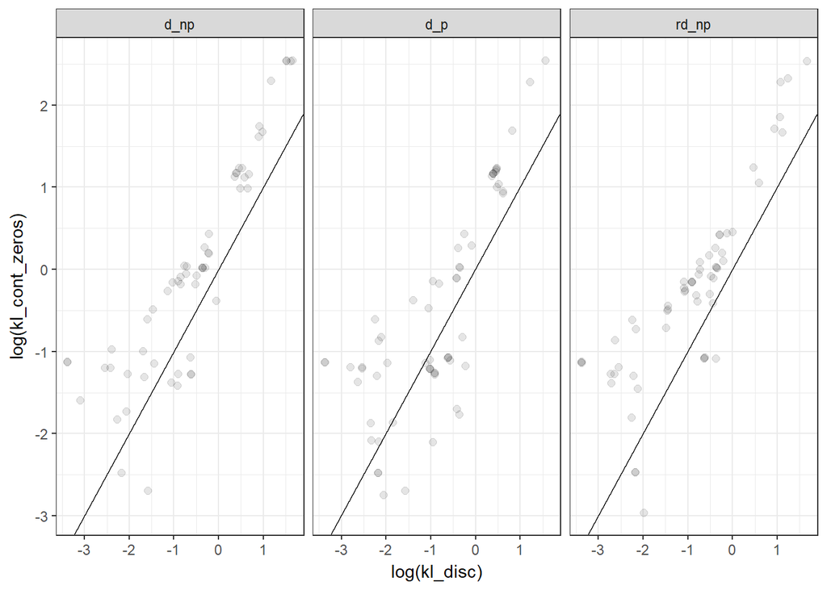

```r
df2dp %>%
  ggplot(aes(x = log(kl_disc), y = log(kl_cont_zeros))) +
  geom_point(position=position_jitter(width=.01, height=.01), alpha=.1, pch=19, size=2) +
  geom_abline(intercept = 0, slope = 1) +
  facet_wrap(~ condition)
```

### Continuous KLD

And for the continuous responses:

```r
# method 1
df2cp$kl_disc = apply(df2cp, 1, function(row) {
  guessed_y = as.numeric(strsplit(as.character(row["binprob"]), ",")[[1]])
  guessed_x = as.numeric(strsplit(as.character(row["binx"]), "_")[[1]])
  kld_continuous(transfer_spence_predictive_ref_dist, guessed_x, guessed_y)
})

# method 2 / 3
df2cp$kl_cont_zeros = apply(df2cp, 1, function(row) {
  guessed_y = as.numeric(strsplit(as.character(row["binprob"]), ",")[[1]])
  guessed_x = as.numeric(strsplit(as.character(row["binx"]), "_")[[1]])
  kld(dnorm(guessed_x, transfer_true_mu, transfer_true_se), guessed_y/sum(guessed_y))
})
df2cp$kl_disc_zeros = df2cp$kl_cont_zeros

# method 1 for true sampling dist
df2cp$true_sampling_kl = apply(df2cp, 1, function(row) {
  guessed_y = as.numeric(strsplit(as.character(row["binprob"]), ",")[[1]])
  guessed_x = as.numeric(strsplit(as.character(row["binx"]), "_")[[1]])
  kld_continuous(transfer_true_sampling_ref_dist, guessed_x, guessed_y)
})

# method 1 for true sampling dist
df2cp$observed_sampling_kl = apply(df2cp, 1, function(row) {
  guessed_y = as.numeric(strsplit(as.character(row["binprob"]), ",")[[1]])
  guessed_x = as.numeric(strsplit(as.character(row["binx"]), "_")[[1]])
  kld_continuous(transfer_observed_sampling_ref_dist, guessed_x, guessed_y)
})
```

#### Comparing the methods

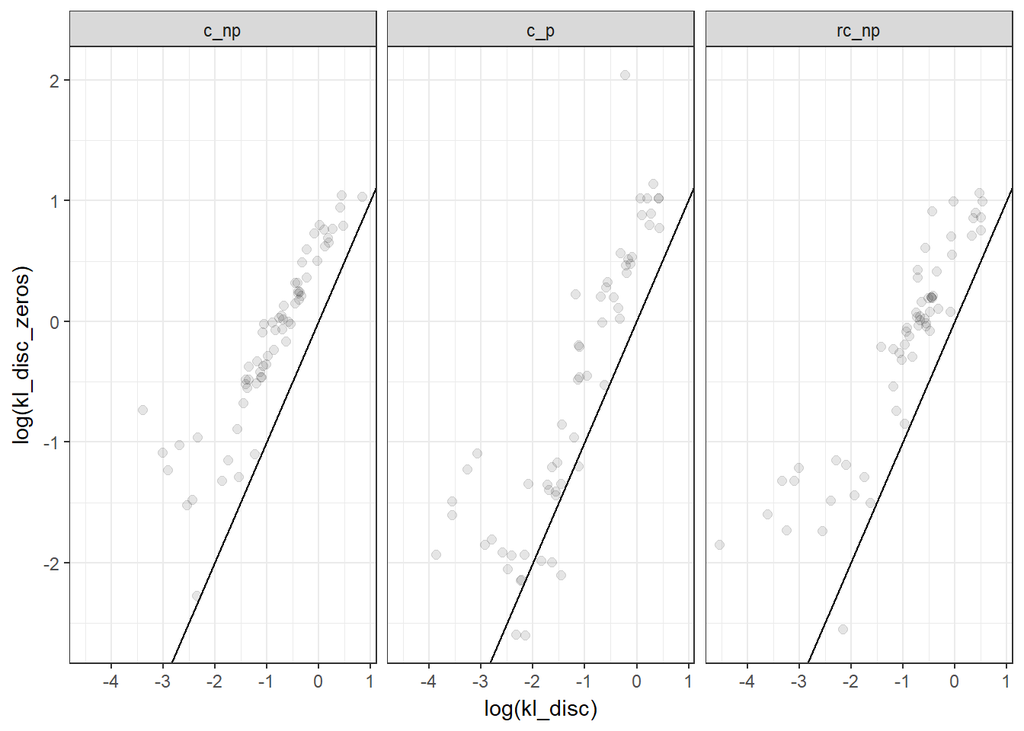

```r
df2cp %>%
  ggplot(aes(x = log(kl_disc), y = log(kl_disc_zeros))) +
  geom_point(position=position_jitter(width=.01, height=.01), alpha=.1, pch=19, size=2) +
  geom_abline(intercept = 0, slope = 1) +
  facet_wrap(~ condition)
```

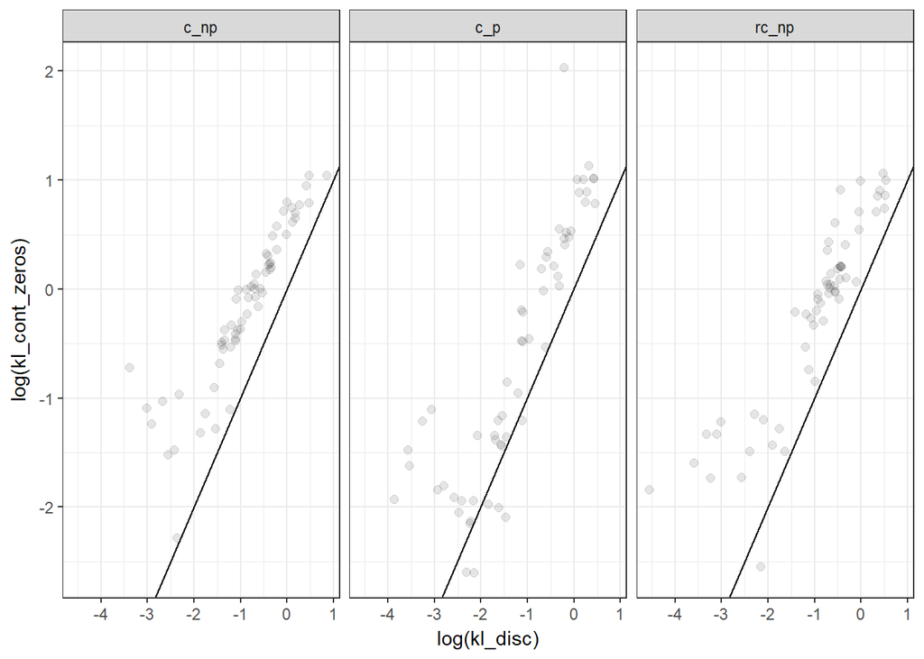

```r
df2cp %>%
  ggplot(aes(x = log(kl_disc), y = log(kl_cont_zeros))) +
  geom_point(position=position_jitter(width=.01, height=.01), alpha=.1, pch=19, size=2) +
  geom_abline(intercept = 0, slope = 1) +
  facet_wrap(~ condition)
```

## Combine the discrete and continuous

Then combine the discrete and continuous and add prescore:

```r
adfp <- rbind(df2dp, df2cp)

adfp = merge(adfp, worker_prescore, by = intersect(names(adfp), names(worker_prescore)))
```

## Descriptive statistics

```r
adfp %<>% mutate(
  discrete = ifelse(condition == "d_p" | condition == "d_np" | condition == "r_np", 1, 0),
  predict = ifelse(condition == "d_p" | condition == "c_p", 1, 0),
  rules = ifelse(condition == "rd_np" | condition == "rc_np", 1, 0)
)
```

Log of KLD across conditions:

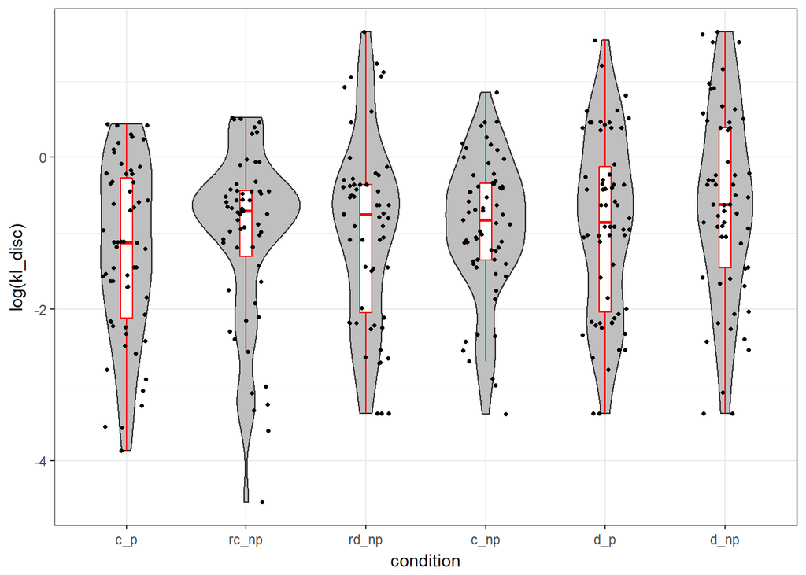

```r
adfp %>%
  mutate(condition = reorder(condition, log(kl_disc))) %>%
  ggplot(aes(x = condition, y = log(kl_disc))) +
  geom_violin(fill = "gray75") +
  geom_boxplot(width = 0.1, color = "red", outlier.color = NA) +
  geom_jitter(pch=20, width = .2)
```

```r
ddply(adfp, ~condition, summarise,
  mean=mean(merrs, na.rm=TRUE), sd=sd(merrs, na.rm=TRUE),
  median = median(merrs, na.rm=TRUE),
  mad = mad(merrs, na.rm=TRUE))
```

```
##   condition      mean        sd     median       mad
## 1      c_np 0.4497292 0.6210576 0.44269079 0.6895358
## 2       c_p 0.2852792 0.4432633 0.04759737 0.2474620
## 3      d_np 0.4419082 0.6141566 0.48750000 0.7227675
## 4       d_p 0.2319385 0.4303560 0.20000000 0.3706500
## 5     rc_np 0.4772264 0.4962018 0.53402105 0.5085435
## 6     rd_np 0.4529497 0.4638311 0.52500000 0.2965200
```

```r
ddply(adfp, ~condition, summarise,
  mean=mean(serrs, na.rm=TRUE), sd=sd(serrs, na.rm=TRUE),
  median = median(serrs, na.rm=TRUE),
  mad = mad(serrs, na.rm=TRUE))
```

```
##   condition        mean        sd      median       mad
## 1      c_np -0.07152851 0.4042025 -0.13408575 0.4214122
## 2       c_p  0.04591096 0.2414250  0.05930822 0.2131637
## 3      d_np -0.30186640 0.3152228 -0.22881204 0.2910780
## 4       d_p -0.18365316 0.2244993 -0.12928763 0.1550967
## 5     rc_np -0.02799731 0.3047051 -0.11683831 0.2873155
## 6     rd_np -0.39832279 0.2984637 -0.35448321 0.2689621
```

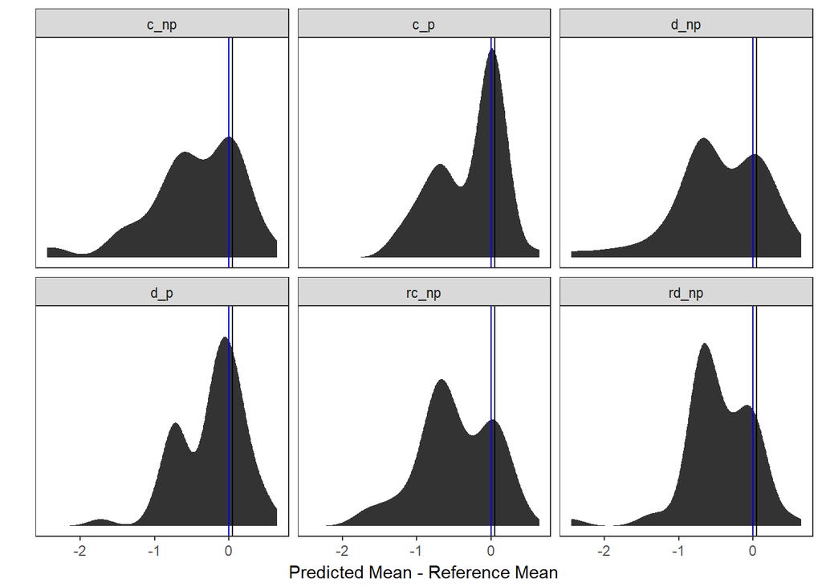

```r
#plots

adfp %>%
ggplot(aes(x = means - 0.7)) + stat_density() +
    facet_wrap(~condition) +
    geom_vline(xintercept = 0, color="blue") + theme(axis.text.y=element_blank(),axis.ticks.y=element_blank(), panel.grid.major = element_blank(), panel.grid.minor = element_blank()) + labs(x="Predicted Mean - Reference Mean",  y="") + geom_vline(xintercept = 0.05, color="black")
```

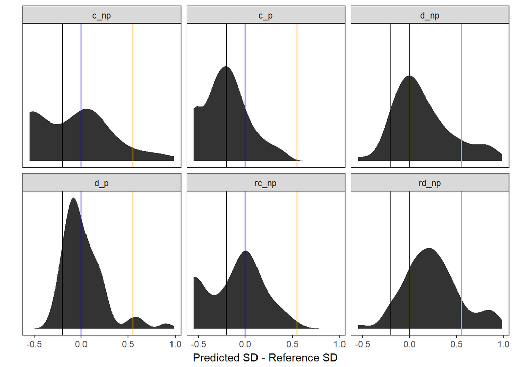

```r
adfp %>%
ggplot(aes(x = sds - sqrt(2)*(1.1/sqrt(8)))) + stat_density() +
    facet_wrap(~condition) +
    geom_vline(xintercept = 0, color="blue") + theme(axis.text.y=element_blank(),axis.ticks.y=element_blank(), panel.grid.major = element_blank(), panel.grid.minor = element_blank()) + labs(x="Predicted SD - Reference SD",  y="") + geom_vline(xintercept = -0.20, color="black") + geom_vline(xintercept=0.55, color="orange")
```

## Frequentist model

```r
#center prescore
adfp$prescore_c <- adfp$prescore - mean(adfp$prescore)

adfp_gamlss = adfp %>%
  dplyr::select(discrete, predict, rules, prescore_c, kl_disc, kl_disc_zeros, kl_cont_zeros, workerId) #gamlss needs all columns without NAs

mg = gamlss(log(kl_disc) ~ discrete*predict + rules+prescore_c,
  sigma.formula = ~ discrete*predict + rules+prescore_c,
  data=adfp_gamlss)
```

```
## GAMLSS-RS iteration 1: Global Deviance = 1066.671
## GAMLSS-RS iteration 2: Global Deviance = 1066.48
## GAMLSS-RS iteration 3: Global Deviance = 1066.479
```

```r
summary(mg)
```

```
## Family:  c("NO", "Normal")
##
## Call:  gamlss(formula = log(kl_disc) ~ discrete * predict +
##     rules + prescore_c, sigma.formula = ~discrete *
##     predict + rules + prescore_c, data = adfp_gamlss)
##
## Fitting method: RS()
##
## ------------------------------------------------------------------
## Mu link function:  identity
## Mu Coefficients:
##                   Estimate Std. Error t value Pr(>|t|)
## (Intercept)      -0.956392   0.105653  -9.052  < 2e-16 ***
## discrete          0.333085   0.189408   1.759   0.0795 .
## predict          -0.281609   0.175620  -1.604   0.1097
## rules            -0.007262   0.143487  -0.051   0.9597
## prescore_c       -0.231505   0.040873  -5.664  3.1e-08 ***
## discrete:predict  0.008835   0.278769   0.032   0.9747
## ---
## Signif. codes:  0 '***' 0.001 '**' 0.01 '*' 0.05 '.' 0.1 ' ' 1
##
## ------------------------------------------------------------------
## Sigma link function:  log
## Sigma Coefficients:
##                  Estimate Std. Error t value Pr(>|t|)
## (Intercept)      -0.17086    0.08914  -1.917  0.05609 .
## discrete          0.36479    0.12885   2.831  0.00491 **
## predict           0.25674    0.12815   2.003  0.04590 *
## rules             0.23599    0.11066   2.133  0.03366 *
## prescore_c        0.06530    0.02807   2.326  0.02059 *
## discrete:predict -0.30250    0.18244  -1.658  0.09820 .
## ---
## Signif. codes:  0 '***' 0.001 '**' 0.01 '*' 0.05 '.' 0.1 ' ' 1
##
## ------------------------------------------------------------------
## No. of observations in the fit:  360
## Degrees of Freedom for the fit:  12
##       Residual Deg. of Freedom:  348
##                       at cycle:  3
##
## Global Deviance:     1066.48
##             AIC:     1090.48
##             SBC:     1137.113
```

## Bayesian model

We will re-use the same model specification as in the recall task, but now for the transfer task:

```r
m_transfer_disc = map2stan(kld_model_spec, data = adfp_gamlss %>% rename(kl = kl_disc))
```

```
## recompiling to avoid crashing R session
```

[output not shown]

```
## Computing WAIC
```

```
## Constructing posterior predictions
```

```
## [ 100 / 1000 ]
[ 200 / 1000 ]
[ 300 / 1000 ]
[ 400 / 1000 ]
[ 500 / 1000 ]
[ 600 / 1000 ]
[ 700 / 1000 ]
[ 800 / 1000 ]
[ 900 / 1000 ]
[ 1000 / 1000 ]
```

```r
m_transfer_disc_zeros = map2stan(kld_model_spec, data = adfp_gamlss %>% rename(kl = kl_disc_zeros))
```

```
## recompiling to avoid crashing R session
```

[output not shown]

```
## Computing WAIC
## Constructing posterior predictions
```

```
## [ 100 / 1000 ]
[ 200 / 1000 ]
[ 300 / 1000 ]
[ 400 / 1000 ]
[ 500 / 1000 ]
[ 600 / 1000 ]
[ 700 / 1000 ]
[ 800 / 1000 ]
[ 900 / 1000 ]
[ 1000 / 1000 ]
```

```r
m_transfer_cont_zeros = map2stan(kld_model_spec, data = adfp_gamlss %>% rename(kl = kl_cont_zeros))
```

```
## recompiling to avoid crashing R session
```

[output not shown]

```
## Computing WAIC
## Constructing posterior predictions
```

```
## [ 100 / 1000 ]
[ 200 / 1000 ]
[ 300 / 1000 ]
[ 400 / 1000 ]
[ 500 / 1000 ]
[ 600 / 1000 ]
[ 700 / 1000 ]
[ 800 / 1000 ]
[ 900 / 1000 ]
[ 1000 / 1000 ]
```